# ROADMAP: Simulated Trial Behaviour (sim09)

Published

October 28, 2026

# About this report

ROADMAP is an adaptive platform trial in prosthetic joint infection. It has four domains and is designed to stop recruiting into a domain when the accumulated evidence is strong enough but continue recruitment into the other domains. Loosely, the four questions are:

- **D1 - Surgical strategy:** is revision surgery (removing and replacing the joint) better than DAIR (debridement and implant retention) for patients with a late-acute infection?
- **D2 - Antibiotic duration:** among patients having a one-stage revision (r1), is a shorter (6-week) course of antibiotics as non-inferior to a 12-week course?
- **D3 - Extended prophylaxis:** among patients having a two-stage revision (r2), does an extra 12 weeks of preventive antibiotics improve outcomes compared with none?
- **D4 - Rifampicin:** does adding rifampicin to the antibiotic regimen improve outcomes?

At each interim analysis, the trial looks at the data collected to date for each of these four questions and asks whether the evidence is strong enough to draw a conclusion. If so, the simulation stops randomising patients to that question and adopts the better (or, for d2, non-inferior) option going forward. Futility stopping is also implemented where stopping occurs due to weak levels of support for addressing the questions of interest.

This report describes the revised simulations results where the simulations are of hypothetical runs of the trial design under a range of assumed “true” states of the world.

Each scenario below assumes a different combination of true effects across the four domains. Most commonly, one domain is set up to have a real effect and the rest are set at zero, so the design’s ability to correctly identify a real effect (and correctly recognise a null one elsewhere) can be checked domain by domain. Some domains are dependent on one another so effects in one result in effects manifesting in another.

This report covers 10 scenario(s):

- All domains log OR zero
- d1 l-OR = 0.5
- d1 l-OR = 0.3
- d4 l-OR = 0.5
- d4 l-OR = 0.3
- d2 l-OR = -0.305
- d2 l-OR = 0.214
- d3 l-OR = 0.564
- d3 l-OR = 0.25
- Mix d2 l-OR = -0.1, d3 l-OR = 0.7, d4 l-OR = 0.3

The results data are those stored in **sim09-19** and have **2000** iterations per scenario.

# How to read the results

For each scenario, we are reporting three things:

1. **Chance of reaching each decision, by interim** - across many simulated trials, what proportion concluded superiority / non-inferiority / futility for each domain, by each interim analysis.
2. **Typical patient numbers** - how many patients are typically enrolled, and how many directly inform each domain’s own comparison, by the time a decision is reached.
3. **Recovered vs. true effect** - whether the trial’s own estimate of each effect (averaged across simulated repeats) tracks the assumed true value.

An overall summary across scenarios (chance of each decision by interim, and patient numbers) comes first, followed by the scenario-by-scenario results.

A full set of the underlying numerical tables (bias, root-mean-square error, coverage, and regimen-level weights) is in the Appendix.

# Simulation configuration

The table(s) below describe parts of the design that are the same across every scenario in this report - only the assumed true effects (covered scenario by scenario, below) differ.

Only the late-acute silo that enters into randomised treatment for DAIR versus revision. The other three groups (late-acute patients outside the randomisation window, early infections, and chronic infections) receive whichever surgical strategy their clinician deems appropriate.

## Analysis model

The analysis model includes an intercept, a 4x3 matrix of parameters to address silo and d1 effect and vector terms for d2, d3 and d4. Each of d2, d3 and d4 contains parameters to account for non-randomised treatment/non-reveal along with assignment to the possible randomised treatment strategies.

Treatment effects for d1 contrast late silo dair versus revision participants. However, whereas the response on dair is represented via a single regimen, the revision effects are formed from a mixture of regimens, weighted accordingly (see Appendix for regimens and weights). Implicitly, what is observed in the surgical domain has a dependency on the downstream treatment strategy because d2 and d3 only ever happen for revision patients.

For d2 and d3, deriving the conditional log-odds contrast using weights is overkill, but it gives the same result as referencing the parameter contrasts directly. However, the current design reports standardised marginal effects on both log-odds and risk scales. For the log-odds ratio, this involves averaging the probability over the standardisation population then converting to log-odds and taking the difference. For the risk difference, this involves just averaging the probability over the standardisation population and then doing the contrast.

## Decision rules

For each domain, a decision is reached once the trial is sufficiently confident that the true effect exceeds (or, for futility, falls short of) a pre-specified margin. The decision rules are mutual exclusive to prevent conclusions being simultaneously superior (or ni) and futile. This is not the case for the asymmetric rules, although the chance of it happening even in the asymmetric setup is small.

Decision rules by domain

| Rule | Effect margin (delta) | Confidence required |
| --- | --- | --- |
| D1: Surgical strategy |  |  |
| Superiority | +0.000 | 95% |
| Futility | +0.050 | 30% |
| D2: Antibiotic duration |  |  |
| Non-inferiority | -0.050 | 95% |
| Futility | +0.000 | 10% |
| D3: Extended prophylaxis |  |  |
| Superiority | +0.000 | 95% |
| Futility | +0.050 | 30% |
| D4: Rifampicin |  |  |
| Superiority | +0.000 | 99% |
| Futility | +0.050 | 30% |

# Overall summary across scenarios

This section puts all scenarios side by side, so the behaviour of each comparison can be seen across the range of assumed truths. The scenario-by-scenario detail (including how well each effect is recovered) follows in the next section.

## Chance of each decision

For each domain, the first decision reached locks that domain. The remainder (100% less the decision columns) is the chance that the domain is still open at the final interim. The first table gives the position at the final interim (interim 5, cumulative enrolment of 2500). The domain tabs that follow show how those chances build up over the interim analyses (cumulative enrolment at interims 1 to 5 is 500, 1000, 1500, 2000, 2500). The true effect for each scenario is on the risk-difference scale in percentage points (pp).

Chance of each decision by interim 5

| Scenario | True effects (RD, pp) | D1: Surgical strategy Superiority | D1: Surgical strategy Futility | D2: Antibiotic duration Non-inferiority | D2: Antibiotic duration Futility | D3: Extended prophylaxis Superiority | D3: Extended prophylaxis Futility | D4: Rifampicin Superiority | D4: Rifampicin Futility |
| --- | --- | --- | --- | --- | --- | --- | --- | --- | --- |
| All domains log OR zero | None (all null) | 12% | 88% | 33% | 24% | 13% | 78% | 3% | 95% |
| d1 l-OR = 0.5 | d1: +11.2 | 91% | 9% | 40% | 25% | 12% | 85% | 2% | 97% |
| d1 l-OR = 0.3 | d1: +6.9 | 66% | 32% | 40% | 23% | 12% | 83% | 3% | 96% |
| d4 l-OR = 0.5 | d4: +11.2 | 11% | 88% | 35% | 22% | 12% | 78% | 95% | 4% |
| d4 l-OR = 0.3 | d4: +6.9 | 10% | 89% | 33% | 24% | 13% | 79% | 64% | 32% |
| d2 l-OR = -0.305 | d1: -1.0, d2: -7.5 | 7% | 92% | 8% | 62% | 12% | 80% | 3% | 96% |
| d2 l-OR = 0.214 | d1: +0.7, d2: +5.0 | 15% | 84% | 64% | 8% | 12% | 80% | 4% | 96% |
| d3 l-OR = 0.564 | d1: +2.6, d3: +12.5 | 31% | 67% | 33% | 24% | 81% | 14% | 3% | 96% |
| d3 l-OR = 0.25 | d1: +1.2, d3: +5.8 | 15% | 84% | 36% | 23% | 40% | 46% | 3% | 96% |
| Mix d2 l-OR = -0.1, d3 l-OR = 0.7, d4 l-OR = 0.3 | d1: +2.7, d2: -2.4, d3: +14.5, d4: +6.8 | 34% | 65% | 25% | 34% | 90% | 8% | 65% | 31% |

**D1: Surgical strategy**

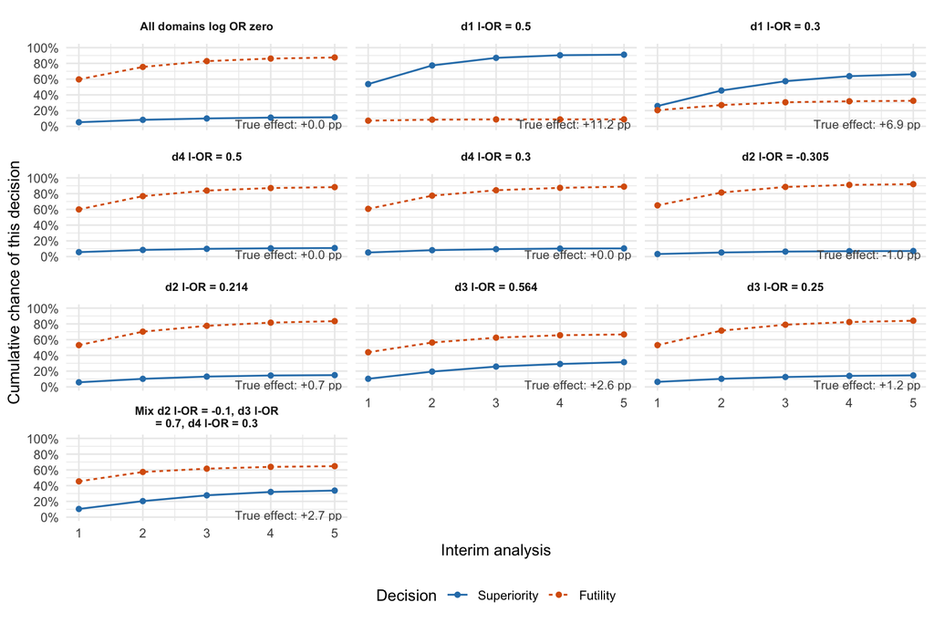

| Decision | Interim 1 | Interim 2 | Interim 3 | Interim 4 | Interim 5 |
| --- | --- | --- | --- | --- | --- |
| All domains log OR zero (true effect +0.0 pp) |  |  |  |  |  |
| Superiority | 5% | 8% | 10% | 11% | 12% |
| Futility | 60% | 75% | 83% | 86% | 88% |
| d1 l-OR = 0.5 (true effect +11.2 pp) |  |  |  |  |  |
| Superiority | 54% | 77% | 87% | 90% | 91% |
| Futility | 7% | 8% | 9% | 9% | 9% |
| d1 l-OR = 0.3 (true effect +6.9 pp) |  |  |  |  |  |
| Superiority | 26% | 46% | 57% | 64% | 66% |
| Futility | 20% | 27% | 31% | 32% | 32% |
| d4 l-OR = 0.5 (true effect +0.0 pp) |  |  |  |  |  |
| Superiority | 6% | 8% | 10% | 11% | 11% |
| Futility | 60% | 77% | 84% | 87% | 88% |
| d4 l-OR = 0.3 (true effect +0.0 pp) |  |  |  |  |  |
| Superiority | 5% | 8% | 9% | 10% | 10% |
| Futility | 61% | 77% | 84% | 87% | 89% |
| d2 l-OR = -0.305 (true effect -1.0 pp) |  |  |  |  |  |
| Superiority | 3% | 5% | 6% | 7% | 7% |
| Futility | 65% | 81% | 88% | 91% | 92% |
| d2 l-OR = 0.214 (true effect +0.7 pp) |  |  |  |  |  |
| Superiority | 6% | 10% | 13% | 14% | 15% |
| Futility | 53% | 70% | 78% | 82% | 84% |
| d3 l-OR = 0.564 (true effect +2.6 pp) |  |  |  |  |  |
| Superiority | 10% | 19% | 26% | 29% | 31% |
| Futility | 44% | 56% | 62% | 66% | 67% |
| d3 l-OR = 0.25 (true effect +1.2 pp) |  |  |  |  |  |
| Superiority | 6% | 10% | 12% | 14% | 15% |
| Futility | 53% | 71% | 79% | 82% | 84% |
| Mix d2 l-OR = -0.1, d3 l-OR = 0.7, d4 l-OR = 0.3 (true effect +2.7 pp) |  |  |  |  |  |
| Superiority | 10% | 20% | 28% | 32% | 34% |
| Futility | 45% | 57% | 62% | 64% | 65% |

**D2: Antibiotic duration**

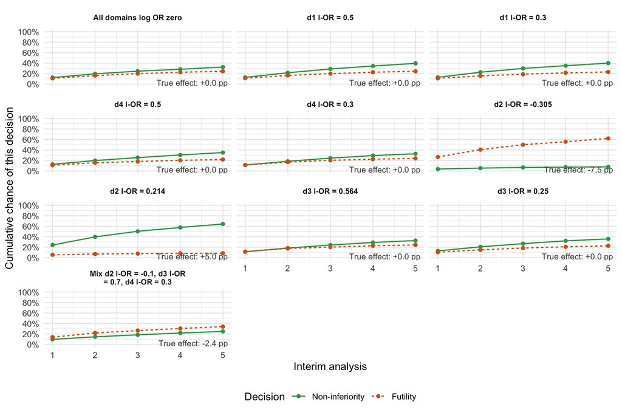

| Decision | Interim 1 | Interim 2 | Interim 3 | Interim 4 | Interim 5 |
| --- | --- | --- | --- | --- | --- |
| All domains log OR zero (true effect +0.0 pp) |  |  |  |  |  |
| Non-inferiority | 13% | 20% | 25% | 28% | 33% |
| Futility | 11% | 16% | 20% | 23% | 24% |
| d1 l-OR = 0.5 (true effect +0.0 pp) |  |  |  |  |  |
| Non-inferiority | 13% | 22% | 29% | 35% | 40% |
| Futility | 11% | 17% | 20% | 23% | 25% |
| d1 l-OR = 0.3 (true effect +0.0 pp) |  |  |  |  |  |
| Non-inferiority | 13% | 23% | 30% | 35% | 40% |
| Futility | 11% | 16% | 19% | 22% | 23% |
| d4 l-OR = 0.5 (true effect +0.0 pp) |  |  |  |  |  |
| Non-inferiority | 13% | 20% | 25% | 30% | 35% |
| Futility | 11% | 16% | 18% | 20% | 22% |
| d4 l-OR = 0.3 (true effect +0.0 pp) |  |  |  |  |  |
| Non-inferiority | 11% | 18% | 24% | 29% | 33% |
| Futility | 11% | 17% | 20% | 22% | 24% |
| d2 l-OR = -0.305 (true effect -7.5 pp) |  |  |  |  |  |
| Non-inferiority | 4% | 5% | 7% | 7% | 8% |
| Futility | 27% | 41% | 50% | 56% | 62% |
| d2 l-OR = 0.214 (true effect +5.0 pp) |  |  |  |  |  |
| Non-inferiority | 24% | 40% | 50% | 58% | 64% |
| Futility | 5% | 7% | 8% | 8% | 8% |
| d3 l-OR = 0.564 (true effect +0.0 pp) |  |  |  |  |  |
| Non-inferiority | 11% | 18% | 24% | 29% | 33% |
| Futility | 12% | 18% | 20% | 23% | 24% |
| d3 l-OR = 0.25 (true effect +0.0 pp) |  |  |  |  |  |
| Non-inferiority | 13% | 21% | 27% | 32% | 36% |
| Futility | 10% | 15% | 18% | 21% | 23% |
| Mix d2 l-OR = -0.1, d3 l-OR = 0.7, d4 l-OR = 0.3 (true effect -2.4 pp) |  |  |  |  |  |
| Non-inferiority | 10% | 15% | 18% | 22% | 25% |
| Futility | 14% | 22% | 26% | 30% | 34% |

**D3: Extended prophylaxis**

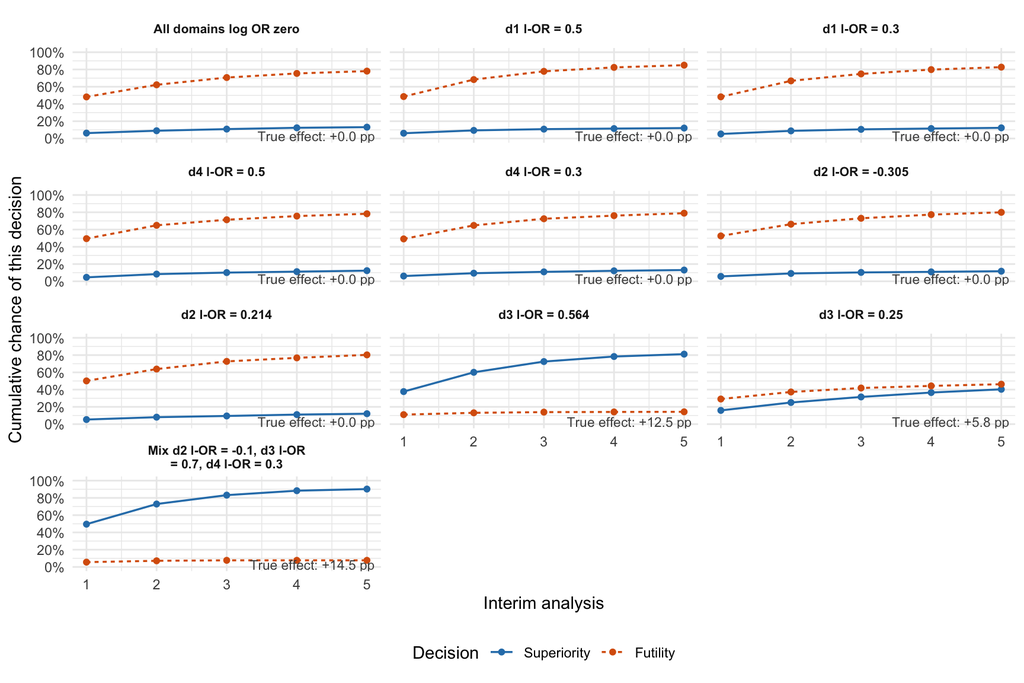

| Decision | Interim 1 | Interim 2 | Interim 3 | Interim 4 | Interim 5 |
| --- | --- | --- | --- | --- | --- |
| All domains log OR zero (true effect +0.0 pp) |  |  |  |  |  |
| Superiority | 6% | 9% | 11% | 12% | 13% |
| Futility | 48% | 62% | 71% | 75% | 78% |
| d1 l-OR = 0.5 (true effect +0.0 pp) |  |  |  |  |  |
| Superiority | 6% | 9% | 11% | 12% | 12% |
| Futility | 49% | 68% | 78% | 82% | 85% |
| d1 l-OR = 0.3 (true effect +0.0 pp) |  |  |  |  |  |
| Superiority | 5% | 9% | 11% | 12% | 12% |
| Futility | 48% | 67% | 75% | 80% | 83% |
| d4 l-OR = 0.5 (true effect +0.0 pp) |  |  |  |  |  |
| Superiority | 5% | 8% | 10% | 11% | 12% |
| Futility | 49% | 65% | 71% | 76% | 78% |
| d4 l-OR = 0.3 (true effect +0.0 pp) |  |  |  |  |  |
| Superiority | 6% | 9% | 11% | 12% | 13% |
| Futility | 49% | 65% | 72% | 76% | 79% |
| d2 l-OR = -0.305 (true effect +0.0 pp) |  |  |  |  |  |
| Superiority | 6% | 9% | 10% | 11% | 12% |
| Futility | 53% | 66% | 73% | 77% | 80% |
| d2 l-OR = 0.214 (true effect +0.0 pp) |  |  |  |  |  |
| Superiority | 5% | 8% | 9% | 11% | 12% |
| Futility | 50% | 64% | 73% | 77% | 80% |
| d3 l-OR = 0.564 (true effect +12.5 pp) |  |  |  |  |  |
| Superiority | 38% | 60% | 72% | 78% | 81% |
| Futility | 11% | 13% | 14% | 14% | 14% |
| d3 l-OR = 0.25 (true effect +5.8 pp) |  |  |  |  |  |
| Superiority | 16% | 25% | 32% | 37% | 40% |
| Futility | 29% | 37% | 42% | 44% | 46% |
| Mix d2 l-OR = -0.1, d3 l-OR = 0.7, d4 l-OR = 0.3 (true effect +14.5 pp) |  |  |  |  |  |
| Superiority | 50% | 73% | 83% | 88% | 90% |
| Futility | 6% | 7% | 8% | 8% | 8% |

**D4: Rifampicin**

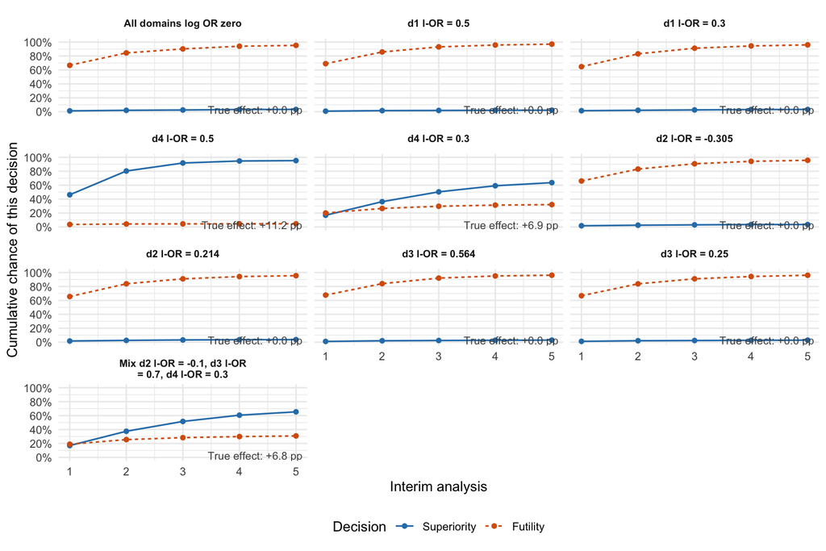

| Decision | Interim 1 | Interim 2 | Interim 3 | Interim 4 | Interim 5 |
| --- | --- | --- | --- | --- | --- |
| All domains log OR zero (true effect +0.0 pp) |  |  |  |  |  |
| Superiority | 1% | 2% | 2% | 3% | 3% |
| Futility | 67% | 84% | 90% | 94% | 95% |
| d1 l-OR = 0.5 (true effect +0.0 pp) |  |  |  |  |  |
| Superiority | 1% | 2% | 2% | 2% | 2% |
| Futility | 69% | 86% | 93% | 96% | 97% |
| d1 l-OR = 0.3 (true effect +0.0 pp) |  |  |  |  |  |
| Superiority | 2% | 2% | 3% | 3% | 3% |
| Futility | 65% | 83% | 91% | 94% | 96% |
| d4 l-OR = 0.5 (true effect +11.2 pp) |  |  |  |  |  |
| Superiority | 46% | 80% | 92% | 95% | 95% |
| Futility | 4% | 4% | 4% | 4% | 4% |
| d4 l-OR = 0.3 (true effect +6.9 pp) |  |  |  |  |  |
| Superiority | 17% | 36% | 50% | 59% | 64% |
| Futility | 20% | 27% | 30% | 31% | 32% |
| d2 l-OR = -0.305 (true effect +0.0 pp) |  |  |  |  |  |
| Superiority | 2% | 2% | 3% | 3% | 3% |
| Futility | 66% | 83% | 91% | 94% | 96% |
| d2 l-OR = 0.214 (true effect +0.0 pp) |  |  |  |  |  |
| Superiority | 2% | 3% | 3% | 4% | 4% |
| Futility | 66% | 84% | 91% | 94% | 96% |
| d3 l-OR = 0.564 (true effect +0.0 pp) |  |  |  |  |  |
| Superiority | 1% | 2% | 2% | 3% | 3% |
| Futility | 68% | 84% | 92% | 95% | 96% |
| d3 l-OR = 0.25 (true effect +0.0 pp) |  |  |  |  |  |
| Superiority | 1% | 2% | 2% | 3% | 3% |
| Futility | 67% | 84% | 91% | 94% | 96% |
| Mix d2 l-OR = -0.1, d3 l-OR = 0.7, d4 l-OR = 0.3 (true effect +6.8 pp) |  |  |  |  |  |
| Superiority | 17% | 38% | 52% | 61% | 65% |
| Futility | 19% | 26% | 28% | 30% | 31% |

## Enrolment and patients informing each decision

These summaries describe the trials in which a decision was reached, at the interim where each domain’s first decision occurred. They should be read alongside the chance of the decision, because a decision that is rarely reached rests on very few simulated trials.

- **Enrolled at decision** is the total number of patients enrolled in the whole platform by that interim, not only those relevant to the domain. Decisions can only occur at an interim analysis, so this is one of the interim enrolment totals (500, 1000, 1500, 2000, 2500) and the average blends them.
- **Informing the decision** is the number of patients contributing to that domain’s own comparison: D1 uses all patients in the late-acute randomised group (DAIR, 1-stage and 2-stage revision), D2 uses 1-stage revision patients randomised to 12 or 6 weeks, D3 uses 2-stage revision patients randomised to 12 weeks or none, and D4 uses patients randomised to rifampicin or not.
- Ranges are the middle 95% across the simulated trials that reached that decision.

**D1: Surgical strategy**

| Decision | Chance of this decision | Enrolled at decision | Informing the decision | Share of enrolled informing |
| --- | --- | --- | --- | --- |
| All domains log OR zero |  |  |  |  |
| Superiority | 12% | 998 (500 to 2500) | 399 (180 to 986) | 40% |
| Futility | 88% | 763 (500 to 2000) | 305 (181 to 811) | 40% |
| d1 l-OR = 0.5 |  |  |  |  |
| Superiority | 91% | 807 (500 to 2000) | 323 (183 to 804) | 40% |
| Futility | 9% | 632 (500 to 1500) | 251 (175 to 591) | 40% |
| d1 l-OR = 0.3 |  |  |  |  |
| Superiority | 66% | 1046 (500 to 2500) | 419 (185 to 997) | 40% |
| Futility | 32% | 807 (500 to 2000) | 322 (179 to 829) | 40% |
| d4 l-OR = 0.5 |  |  |  |  |
| Superiority | 11% | 917 (500 to 2500) | 367 (184 to 968) | 40% |
| Futility | 88% | 757 (500 to 2000) | 303 (179 to 812) | 40% |
| d4 l-OR = 0.3 |  |  |  |  |
| Superiority | 10% | 913 (500 to 2000) | 365 (178 to 821) | 40% |
| Futility | 89% | 757 (500 to 2000) | 303 (181 to 818) | 40% |
| d2 l-OR = -0.305 |  |  |  |  |
| Superiority | 7% | 972 (500 to 2237) | 390 (186 to 922) | 40% |
| Futility | 92% | 729 (500 to 2000) | 291 (180 to 800) | 40% |
| d2 l-OR = 0.214 |  |  |  |  |
| Superiority | 15% | 1040 (500 to 2500) | 418 (183 to 986) | 40% |
| Futility | 84% | 810 (500 to 2000) | 324 (182 to 838) | 40% |
| d3 l-OR = 0.564 |  |  |  |  |
| Superiority | 31% | 1155 (500 to 2500) | 463 (187 to 1017) | 40% |
| Futility | 67% | 786 (500 to 2000) | 314 (181 to 820) | 40% |
| d3 l-OR = 0.25 |  |  |  |  |
| Superiority | 15% | 1027 (500 to 2500) | 410 (182 to 985) | 40% |
| Futility | 84% | 800 (500 to 2000) | 320 (182 to 824) | 40% |
| Mix d2 l-OR = -0.1, d3 l-OR = 0.7, d4 l-OR = 0.3 |  |  |  |  |
| Superiority | 34% | 1161 (500 to 2500) | 465 (187 to 994) | 40% |
| Futility | 65% | 738 (500 to 2000) | 295 (182 to 810) | 40% |

**D2: Antibiotic duration**

| Decision | Chance of this decision | Enrolled at decision | Informing the decision | Share of enrolled informing |
| --- | --- | --- | --- | --- |
| All domains log OR zero |  |  |  |  |
| Non-inferiority | 33% | 1189 (500 to 2500) | 147 (59 to 325) | 13% |
| Futility | 24% | 1069 (500 to 2500) | 134 (62 to 314) | 13% |
| d1 l-OR = 0.5 |  |  |  |  |
| Non-inferiority | 40% | 1259 (500 to 2500) | 200 (61 to 443) | 15% |
| Futility | 25% | 1063 (500 to 2500) | 163 (59 to 434) | 15% |
| d1 l-OR = 0.3 |  |  |  |  |
| Non-inferiority | 40% | 1238 (500 to 2500) | 182 (60 to 426) | 15% |
| Futility | 23% | 1051 (500 to 2500) | 155 (59 to 415) | 15% |
| d4 l-OR = 0.5 |  |  |  |  |
| Non-inferiority | 35% | 1241 (500 to 2500) | 154 (62 to 375) | 13% |
| Futility | 22% | 1018 (500 to 2500) | 127 (60 to 306) | 13% |
| d4 l-OR = 0.3 |  |  |  |  |
| Non-inferiority | 33% | 1223 (500 to 2500) | 152 (60 to 336) | 13% |
| Futility | 24% | 1024 (500 to 2500) | 130 (60 to 314) | 13% |
| d2 l-OR = -0.305 |  |  |  |  |
| Non-inferiority | 8% | 1032 (500 to 2500) | 127 (60 to 282) | 13% |
| Futility | 62% | 1105 (500 to 2500) | 134 (60 to 292) | 13% |
| d2 l-OR = 0.214 |  |  |  |  |
| Non-inferiority | 64% | 1164 (500 to 2500) | 148 (61 to 352) | 13% |
| Futility | 8% | 826 (500 to 2000) | 107 (58 to 269) | 14% |
| d3 l-OR = 0.564 |  |  |  |  |
| Non-inferiority | 33% | 1229 (500 to 2500) | 163 (61 to 412) | 14% |
| Futility | 24% | 1019 (500 to 2500) | 136 (61 to 353) | 14% |
| d3 l-OR = 0.25 |  |  |  |  |
| Non-inferiority | 36% | 1209 (500 to 2500) | 154 (61 to 349) | 13% |
| Futility | 23% | 1070 (500 to 2500) | 136 (60 to 314) | 13% |
| Mix d2 l-OR = -0.1, d3 l-OR = 0.7, d4 l-OR = 0.3 |  |  |  |  |
| Non-inferiority | 25% | 1203 (500 to 2500) | 160 (61 to 413) | 14% |
| Futility | 34% | 1137 (500 to 2500) | 151 (60 to 392) | 14% |

**D3: Extended prophylaxis**

| Decision | Chance of this decision | Enrolled at decision | Informing the decision | Share of enrolled informing |
| --- | --- | --- | --- | --- |
| All domains log OR zero |  |  |  |  |
| Superiority | 13% | 1034 (500 to 2500) | 182 (90 to 390) | 19% |
| Futility | 78% | 858 (500 to 2500) | 159 (87 to 375) | 20% |
| d1 l-OR = 0.5 |  |  |  |  |
| Superiority | 12% | 936 (500 to 2500) | 218 (91 to 671) | 22% |
| Futility | 85% | 870 (500 to 2500) | 202 (88 to 607) | 22% |
| d1 l-OR = 0.3 |  |  |  |  |
| Superiority | 12% | 1032 (500 to 2500) | 226 (92 to 635) | 22% |
| Futility | 83% | 869 (500 to 2500) | 189 (88 to 569) | 21% |
| d4 l-OR = 0.5 |  |  |  |  |
| Superiority | 12% | 1113 (500 to 2500) | 197 (90 to 402) | 19% |
| Futility | 78% | 830 (500 to 2500) | 156 (88 to 393) | 20% |
| d4 l-OR = 0.3 |  |  |  |  |
| Superiority | 13% | 1021 (500 to 2500) | 179 (89 to 376) | 19% |
| Futility | 79% | 837 (500 to 2500) | 155 (87 to 378) | 19% |
| d2 l-OR = -0.305 |  |  |  |  |
| Superiority | 12% | 959 (500 to 2500) | 174 (88 to 402) | 19% |
| Futility | 80% | 817 (500 to 2500) | 151 (88 to 364) | 20% |
| d2 l-OR = 0.214 |  |  |  |  |
| Superiority | 12% | 1095 (500 to 2500) | 197 (89 to 422) | 19% |
| Futility | 80% | 859 (500 to 2500) | 163 (89 to 410) | 20% |
| d3 l-OR = 0.564 |  |  |  |  |
| Superiority | 81% | 967 (500 to 2500) | 187 (90 to 431) | 20% |
| Futility | 14% | 672 (500 to 1500) | 132 (88 to 318) | 20% |
| d3 l-OR = 0.25 |  |  |  |  |
| Superiority | 40% | 1149 (500 to 2500) | 209 (91 to 484) | 19% |
| Futility | 46% | 851 (500 to 2500) | 159 (87 to 402) | 20% |
| Mix d2 l-OR = -0.1, d3 l-OR = 0.7, d4 l-OR = 0.3 |  |  |  |  |
| Superiority | 90% | 871 (500 to 2000) | 168 (88 to 401) | 20% |
| Futility | 8% | 673 (500 to 1500) | 132 (89 to 256) | 20% |

**D4: Rifampicin**

| Decision | Chance of this decision | Enrolled at decision | Informing the decision | Share of enrolled informing |
| --- | --- | --- | --- | --- |
| All domains log OR zero |  |  |  |  |
| Superiority | 3% | 1136 (500 to 2188) | 796 (340 to 1539) | 70% |
| Futility | 95% | 740 (500 to 2000) | 518 (332 to 1406) | 70% |
| d1 l-OR = 0.5 |  |  |  |  |
| Superiority | 2% | 1045 (500 to 2462) | 733 (339 to 1714) | 70% |
| Futility | 97% | 729 (500 to 2000) | 510 (332 to 1398) | 70% |
| d1 l-OR = 0.3 |  |  |  |  |
| Superiority | 3% | 1062 (500 to 2200) | 743 (334 to 1560) | 70% |
| Futility | 96% | 763 (500 to 2000) | 534 (332 to 1407) | 70% |
| d4 l-OR = 0.5 |  |  |  |  |
| Superiority | 95% | 857 (500 to 2000) | 600 (335 to 1394) | 70% |
| Futility | 4% | 644 (500 to 1500) | 450 (332 to 1071) | 70% |
| d4 l-OR = 0.3 |  |  |  |  |
| Superiority | 64% | 1222 (500 to 2500) | 855 (335 to 1760) | 70% |
| Futility | 32% | 823 (500 to 2000) | 576 (330 to 1444) | 70% |
| d2 l-OR = -0.305 |  |  |  |  |
| Superiority | 3% | 957 (500 to 2000) | 667 (326 to 1419) | 70% |
| Futility | 96% | 755 (500 to 2000) | 528 (331 to 1411) | 70% |
| d2 l-OR = 0.214 |  |  |  |  |
| Superiority | 4% | 1014 (500 to 2500) | 713 (337 to 1760) | 70% |
| Futility | 96% | 749 (500 to 2000) | 524 (331 to 1406) | 70% |
| d3 l-OR = 0.564 |  |  |  |  |
| Superiority | 3% | 1095 (500 to 2500) | 768 (338 to 1737) | 70% |
| Futility | 96% | 738 (500 to 2000) | 516 (330 to 1401) | 70% |
| d3 l-OR = 0.25 |  |  |  |  |
| Superiority | 3% | 1061 (500 to 2500) | 743 (339 to 1726) | 70% |
| Futility | 96% | 753 (500 to 2000) | 527 (331 to 1418) | 70% |
| Mix d2 l-OR = -0.1, d3 l-OR = 0.7, d4 l-OR = 0.3 |  |  |  |  |
| Superiority | 65% | 1226 (500 to 2500) | 858 (338 to 1757) | 70% |
| Futility | 31% | 835 (500 to 2500) | 585 (332 to 1723) | 70% |

# Results by scenario

## All domains log OR zero

**Assumed truth**

None of the four questions has a true effect in this scenario - every comparison is exactly zero. This checks that the design does not falsely declare an effect when there isn’t one.

### Chance of reaching each decision

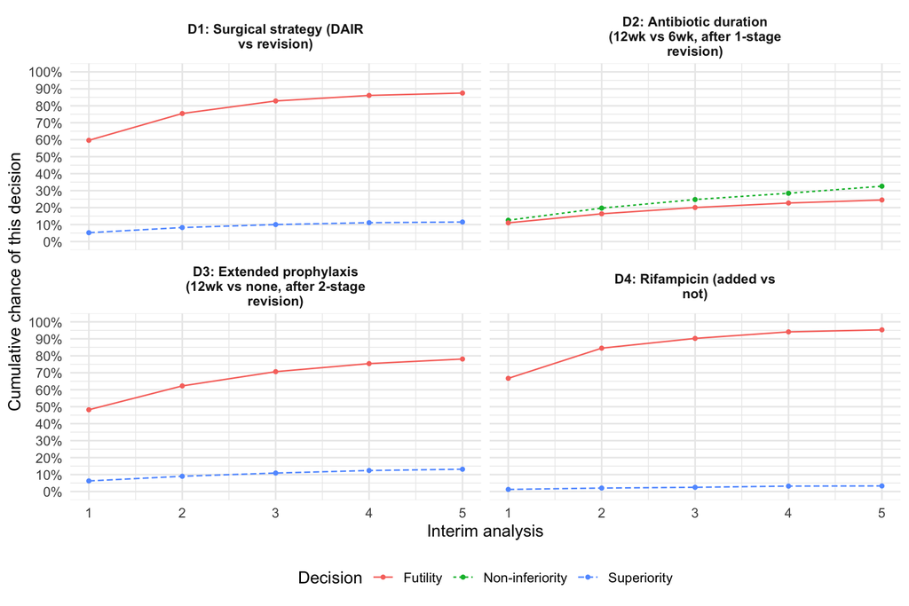

### Typical patient numbers

Patients enrolled by the time a decision is reached

| Domain | Rule | Chance of reaching a decision | Typical no. enrolled at decision | Typical no. informing this decision |
| --- | --- | --- | --- | --- |
| D1: Surgical strategy (DAIR vs revision) | Superiority | 12% | 998 | 399 |
| D1: Surgical strategy (DAIR vs revision) | Futility | 88% | 763 | 305 |
| D2: Antibiotic duration (12wk vs 6wk, after 1-stage revision) | Non-inferiority | 33% | 1189 | 147 |
| D2: Antibiotic duration (12wk vs 6wk, after 1-stage revision) | Futility | 24% | 1069 | 134 |
| D3: Extended prophylaxis (12wk vs none, after 2-stage revision) | Superiority | 13% | 1034 | 182 |
| D3: Extended prophylaxis (12wk vs none, after 2-stage revision) | Futility | 78% | 858 | 159 |
| D4: Rifampicin (added vs not) | Superiority | 3% | 1136 | 796 |
| D4: Rifampicin (added vs not) | Futility | 95% | 740 | 518 |

### Recovered vs. true effect

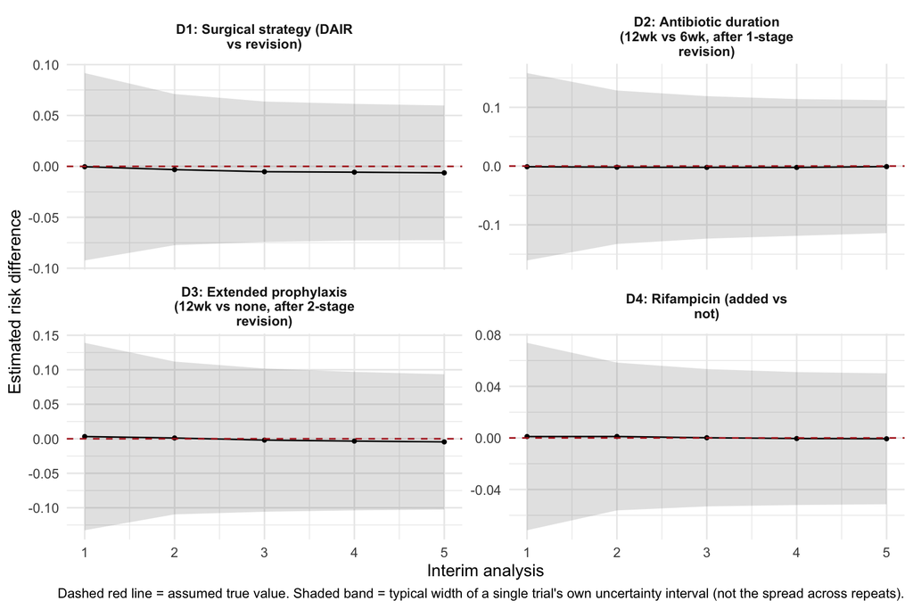

## d1 l-OR = 0.5

**Assumed truth**

**D1: Surgical strategy (DAIR vs revision)** has a true effect of about 11.21 percentage points (risk-difference scale). Any remaining question is set to zero.

### Chance of reaching each decision

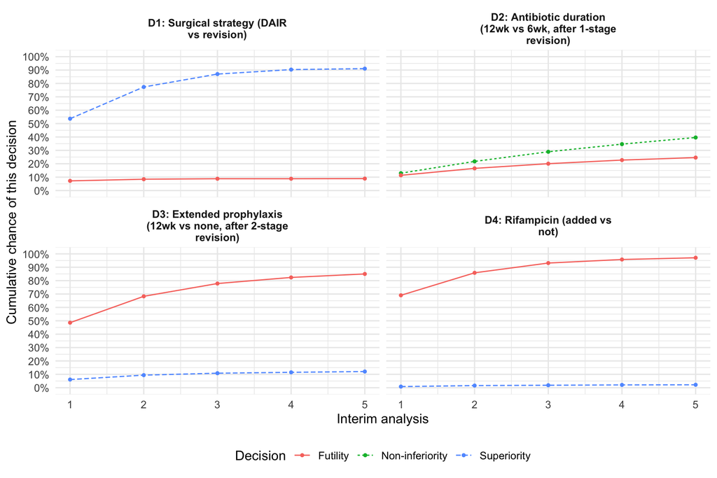

### Typical patient numbers

Patients enrolled by the time a decision is reached

| Domain | Rule | Chance of reaching a decision | Typical no. enrolled at decision | Typical no. informing this decision |
| --- | --- | --- | --- | --- |
| D1: Surgical strategy (DAIR vs revision) | Superiority | 91% | 807 | 323 |
| D1: Surgical strategy (DAIR vs revision) | Futility | 9% | 632 | 251 |
| D2: Antibiotic duration (12wk vs 6wk, after 1-stage revision) | Non-inferiority | 40% | 1259 | 200 |
| D2: Antibiotic duration (12wk vs 6wk, after 1-stage revision) | Futility | 25% | 1063 | 163 |
| D3: Extended prophylaxis (12wk vs none, after 2-stage revision) | Superiority | 12% | 936 | 218 |
| D3: Extended prophylaxis (12wk vs none, after 2-stage revision) | Futility | 85% | 870 | 202 |
| D4: Rifampicin (added vs not) | Superiority | 2% | 1045 | 733 |
| D4: Rifampicin (added vs not) | Futility | 97% | 729 | 510 |

### Recovered vs. true effect

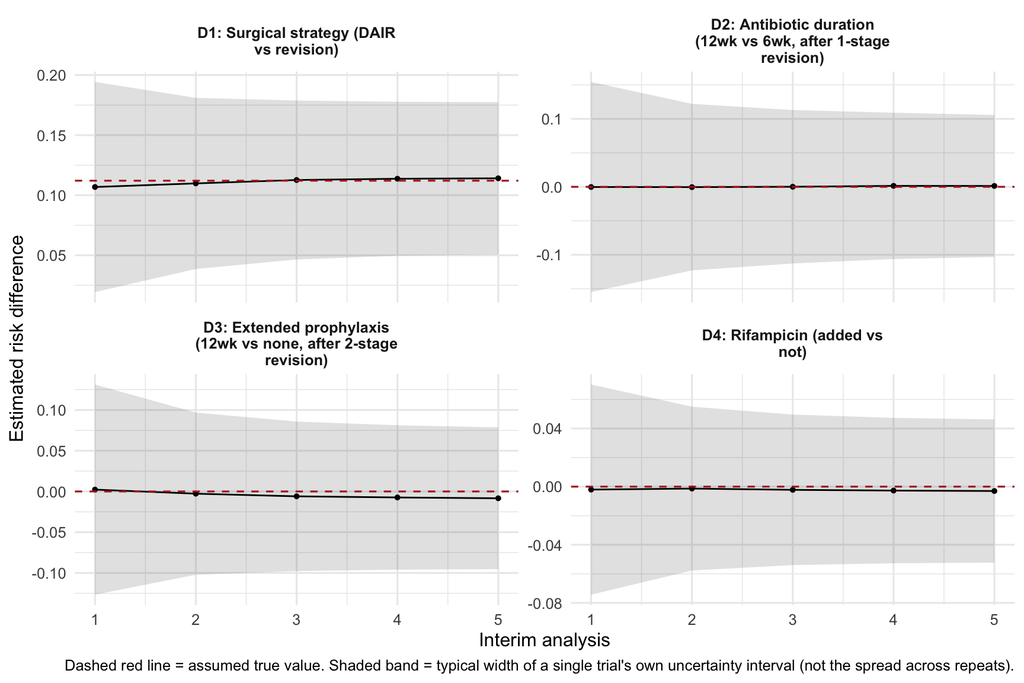

## d1 l-OR = 0.3

**Assumed truth**

**D1: Surgical strategy (DAIR vs revision)** has a true effect of about 6.94 percentage points (risk-difference scale). Any remaining question is set to zero.

### Chance of reaching each decision

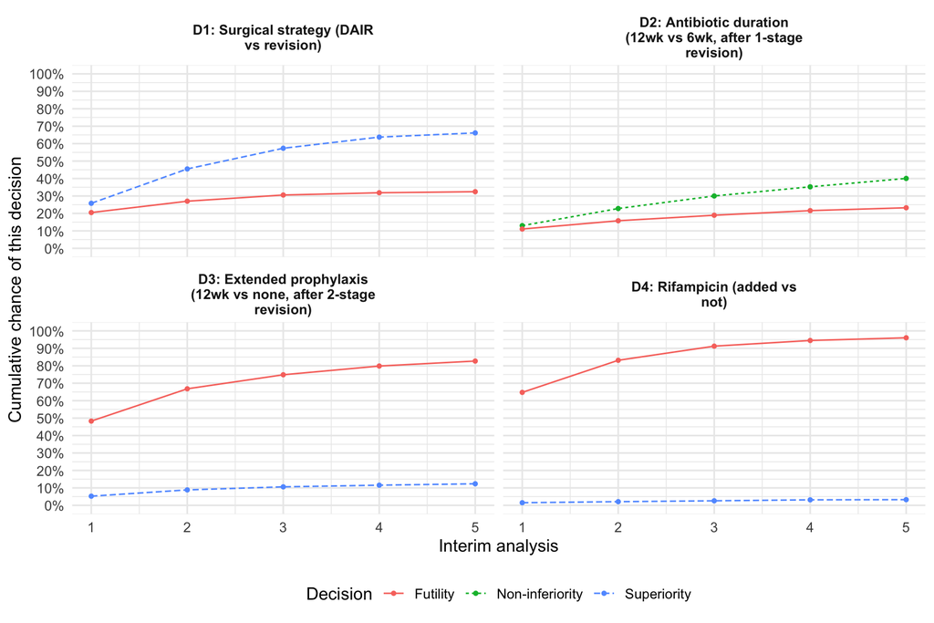

### Typical patient numbers

Patients enrolled by the time a decision is reached

| Domain | Rule | Chance of reaching a decision | Typical no. enrolled at decision | Typical no. informing this decision |
| --- | --- | --- | --- | --- |
| D1: Surgical strategy (DAIR vs revision) | Superiority | 66% | 1046 | 419 |
| D1: Surgical strategy (DAIR vs revision) | Futility | 32% | 807 | 322 |
| D2: Antibiotic duration (12wk vs 6wk, after 1-stage revision) | Non-inferiority | 40% | 1238 | 182 |
| D2: Antibiotic duration (12wk vs 6wk, after 1-stage revision) | Futility | 23% | 1051 | 155 |
| D3: Extended prophylaxis (12wk vs none, after 2-stage revision) | Superiority | 12% | 1032 | 226 |
| D3: Extended prophylaxis (12wk vs none, after 2-stage revision) | Futility | 83% | 869 | 189 |
| D4: Rifampicin (added vs not) | Superiority | 3% | 1062 | 743 |
| D4: Rifampicin (added vs not) | Futility | 96% | 763 | 534 |

### Recovered vs. true effect

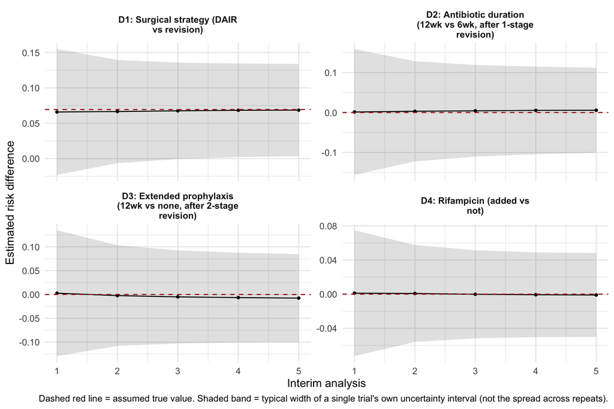

## d4 l-OR = 0.5

**Assumed truth**

**D4: Rifampicin (added vs not)** has a true effect of about 11.21 percentage points (risk-difference scale). Any remaining question is set to zero.

### Chance of reaching each decision

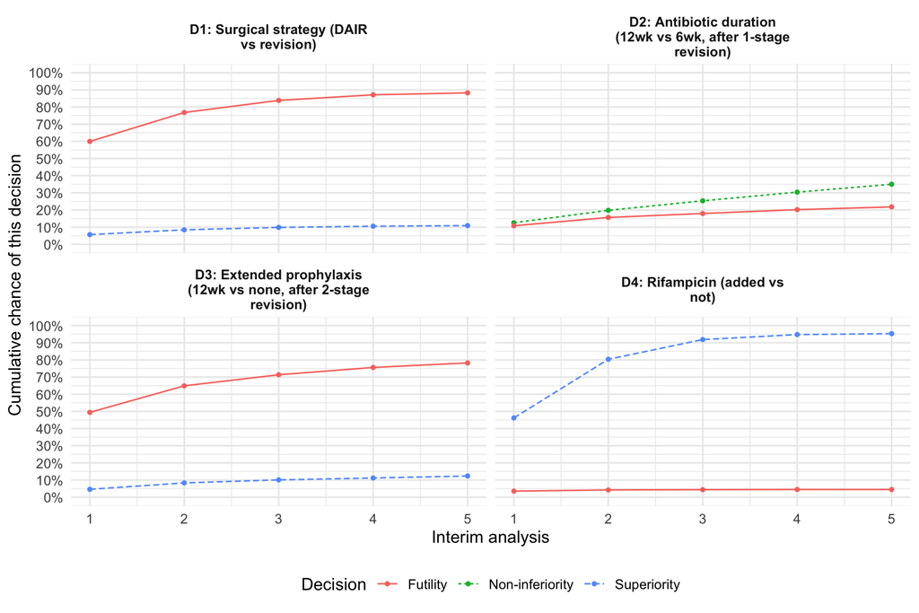

### Typical patient numbers

Patients enrolled by the time a decision is reached

| Domain | Rule | Chance of reaching a decision | Typical no. enrolled at decision | Typical no. informing this decision |
| --- | --- | --- | --- | --- |
| D1: Surgical strategy (DAIR vs revision) | Superiority | 11% | 917 | 367 |
| D1: Surgical strategy (DAIR vs revision) | Futility | 88% | 757 | 303 |
| D2: Antibiotic duration (12wk vs 6wk, after 1-stage revision) | Non-inferiority | 35% | 1241 | 154 |
| D2: Antibiotic duration (12wk vs 6wk, after 1-stage revision) | Futility | 22% | 1018 | 127 |
| D3: Extended prophylaxis (12wk vs none, after 2-stage revision) | Superiority | 12% | 1113 | 197 |
| D3: Extended prophylaxis (12wk vs none, after 2-stage revision) | Futility | 78% | 830 | 156 |
| D4: Rifampicin (added vs not) | Superiority | 95% | 857 | 600 |
| D4: Rifampicin (added vs not) | Futility | 4% | 644 | 450 |

### Recovered vs. true effect

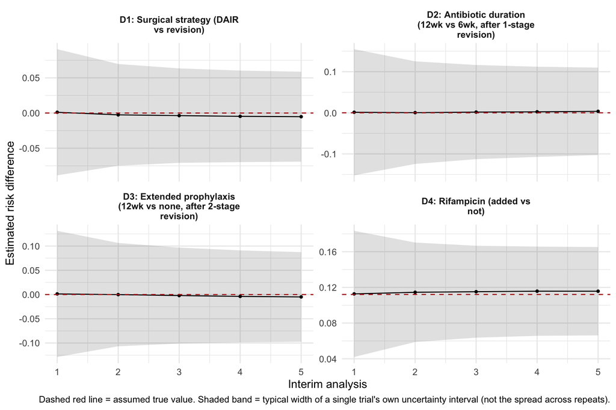

## d4 l-OR = 0.3

**Assumed truth**

**D4: Rifampicin (added vs not)** has a true effect of about 6.94 percentage points (risk-difference scale). Any remaining question is set to zero.

### Chance of reaching each decision

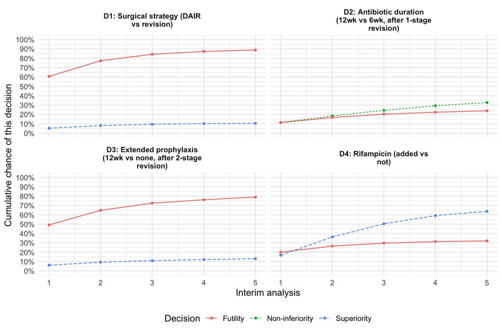

### Typical patient numbers

Patients enrolled by the time a decision is reached

| Domain | Rule | Chance of reaching a decision | Typical no. enrolled at decision | Typical no. informing this decision |
| --- | --- | --- | --- | --- |
| D1: Surgical strategy (DAIR vs revision) | Superiority | 10% | 913 | 365 |
| D1: Surgical strategy (DAIR vs revision) | Futility | 89% | 757 | 303 |
| D2: Antibiotic duration (12wk vs 6wk, after 1-stage revision) | Non-inferiority | 33% | 1223 | 152 |
| D2: Antibiotic duration (12wk vs 6wk, after 1-stage revision) | Futility | 24% | 1024 | 130 |
| D3: Extended prophylaxis (12wk vs none, after 2-stage revision) | Superiority | 13% | 1021 | 179 |
| D3: Extended prophylaxis (12wk vs none, after 2-stage revision) | Futility | 79% | 837 | 155 |
| D4: Rifampicin (added vs not) | Superiority | 64% | 1222 | 855 |
| D4: Rifampicin (added vs not) | Futility | 32% | 823 | 576 |

### Recovered vs. true effect

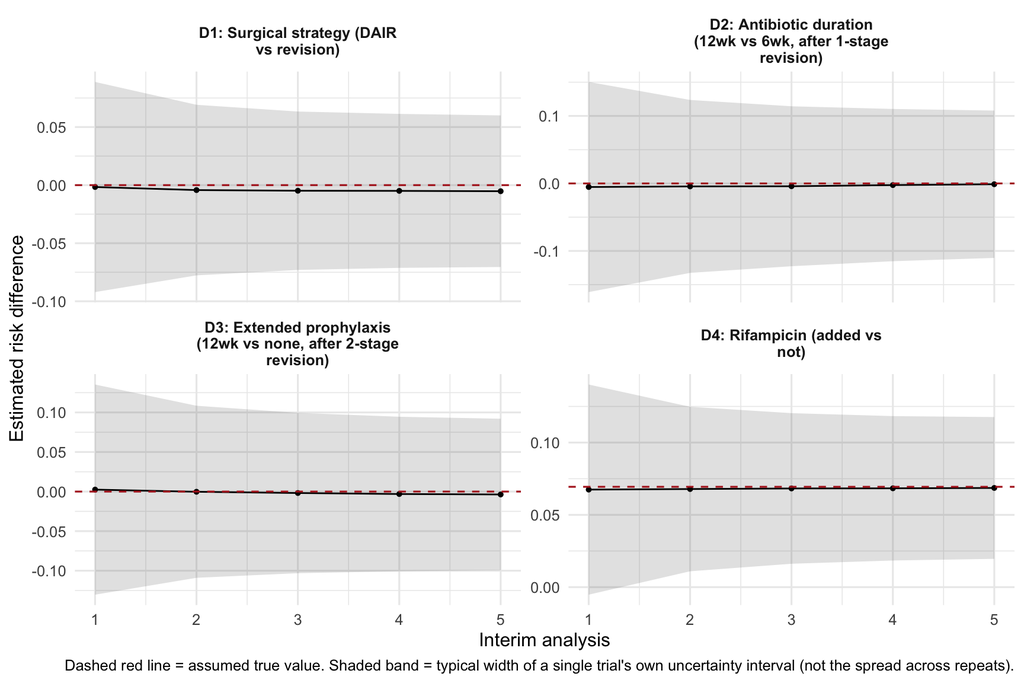

## d2 l-OR = -0.305

**Assumed truth**

**D1: Surgical strategy (DAIR vs revision)** has a true effect of about -1.05 percentage points (risk-difference scale); **D2: Antibiotic duration (12wk vs 6wk, after 1-stage revision)** has a true effect of about -7.49 percentage points (risk-difference scale). Any remaining question is set to zero.

### Chance of reaching each decision

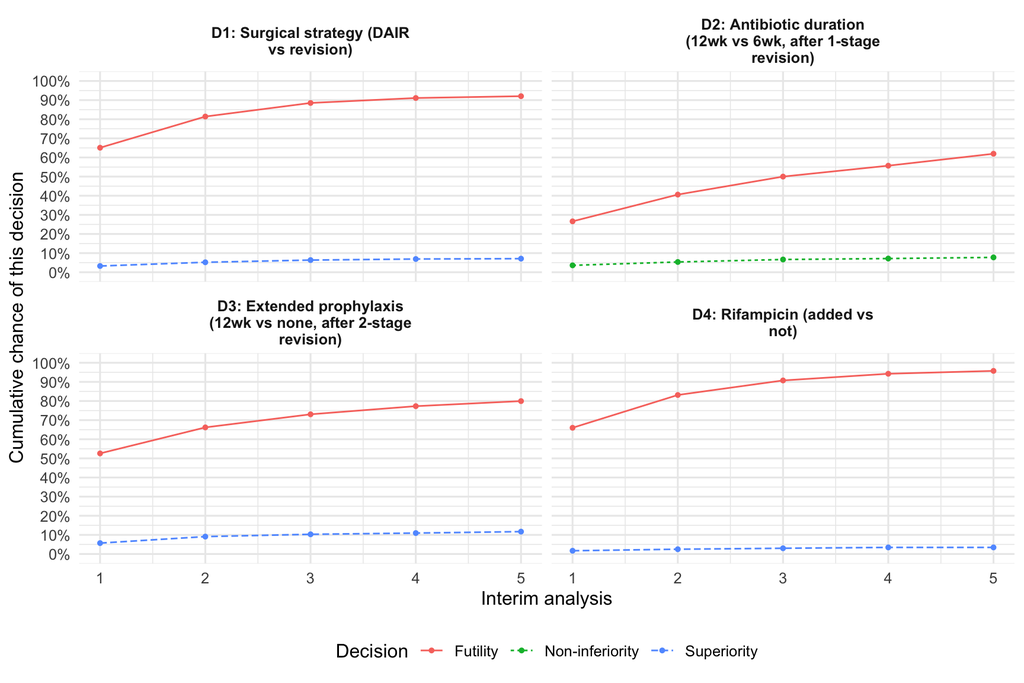

### Typical patient numbers

Patients enrolled by the time a decision is reached

| Domain | Rule | Chance of reaching a decision | Typical no. enrolled at decision | Typical no. informing this decision |
| --- | --- | --- | --- | --- |
| D1: Surgical strategy (DAIR vs revision) | Superiority | 7% | 972 | 390 |
| D1: Surgical strategy (DAIR vs revision) | Futility | 92% | 729 | 291 |
| D2: Antibiotic duration (12wk vs 6wk, after 1-stage revision) | Non-inferiority | 8% | 1032 | 127 |
| D2: Antibiotic duration (12wk vs 6wk, after 1-stage revision) | Futility | 62% | 1105 | 134 |
| D3: Extended prophylaxis (12wk vs none, after 2-stage revision) | Superiority | 12% | 959 | 174 |
| D3: Extended prophylaxis (12wk vs none, after 2-stage revision) | Futility | 80% | 817 | 151 |
| D4: Rifampicin (added vs not) | Superiority | 3% | 957 | 667 |
| D4: Rifampicin (added vs not) | Futility | 96% | 755 | 528 |

### Recovered vs. true effect

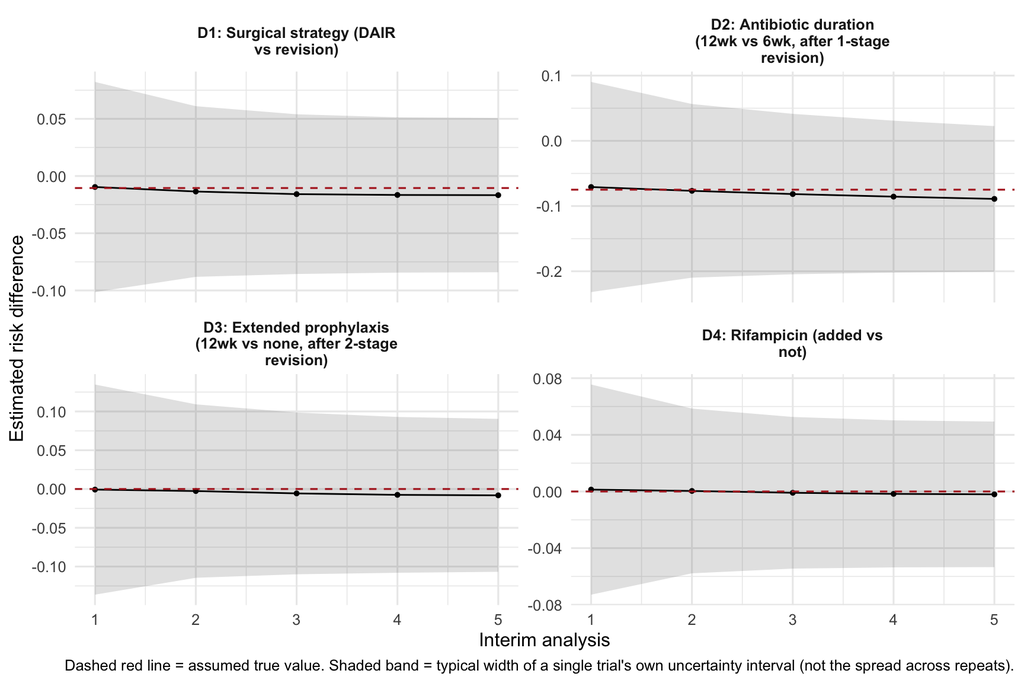

## d2 l-OR = 0.214

**Assumed truth**

**D1: Surgical strategy (DAIR vs revision)** has a true effect of about 0.70 percentage points (risk-difference scale); **D2: Antibiotic duration (12wk vs 6wk, after 1-stage revision)** has a true effect of about 5.01 percentage points (risk-difference scale). Any remaining question is set to zero.

### Chance of reaching each decision

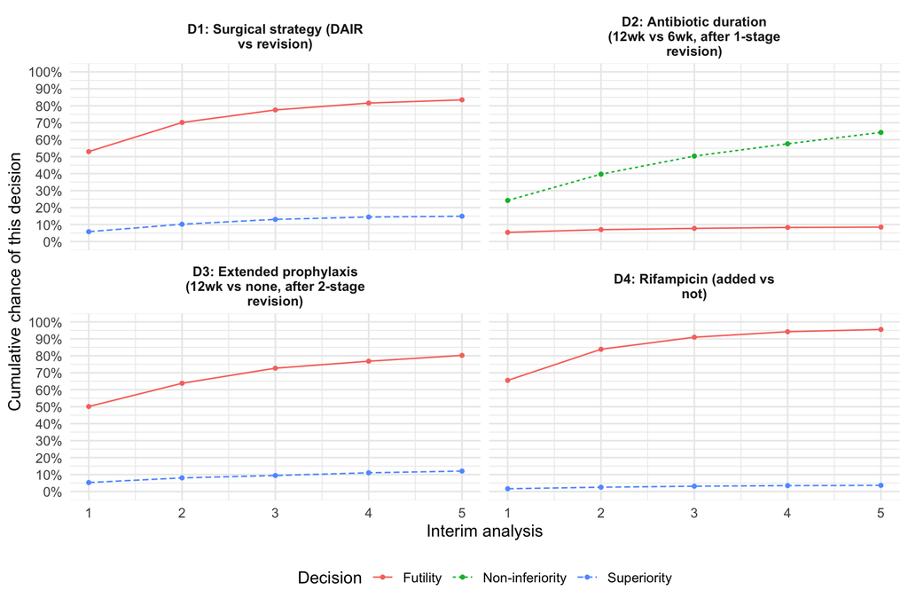

### Typical patient numbers

Patients enrolled by the time a decision is reached

| Domain | Rule | Chance of reaching a decision | Typical no. enrolled at decision | Typical no. informing this decision |
| --- | --- | --- | --- | --- |
| D1: Surgical strategy (DAIR vs revision) | Superiority | 15% | 1040 | 418 |
| D1: Surgical strategy (DAIR vs revision) | Futility | 84% | 810 | 324 |
| D2: Antibiotic duration (12wk vs 6wk, after 1-stage revision) | Non-inferiority | 64% | 1164 | 148 |
| D2: Antibiotic duration (12wk vs 6wk, after 1-stage revision) | Futility | 8% | 826 | 107 |
| D3: Extended prophylaxis (12wk vs none, after 2-stage revision) | Superiority | 12% | 1095 | 197 |
| D3: Extended prophylaxis (12wk vs none, after 2-stage revision) | Futility | 80% | 859 | 163 |
| D4: Rifampicin (added vs not) | Superiority | 4% | 1014 | 713 |
| D4: Rifampicin (added vs not) | Futility | 96% | 749 | 524 |

### Recovered vs. true effect

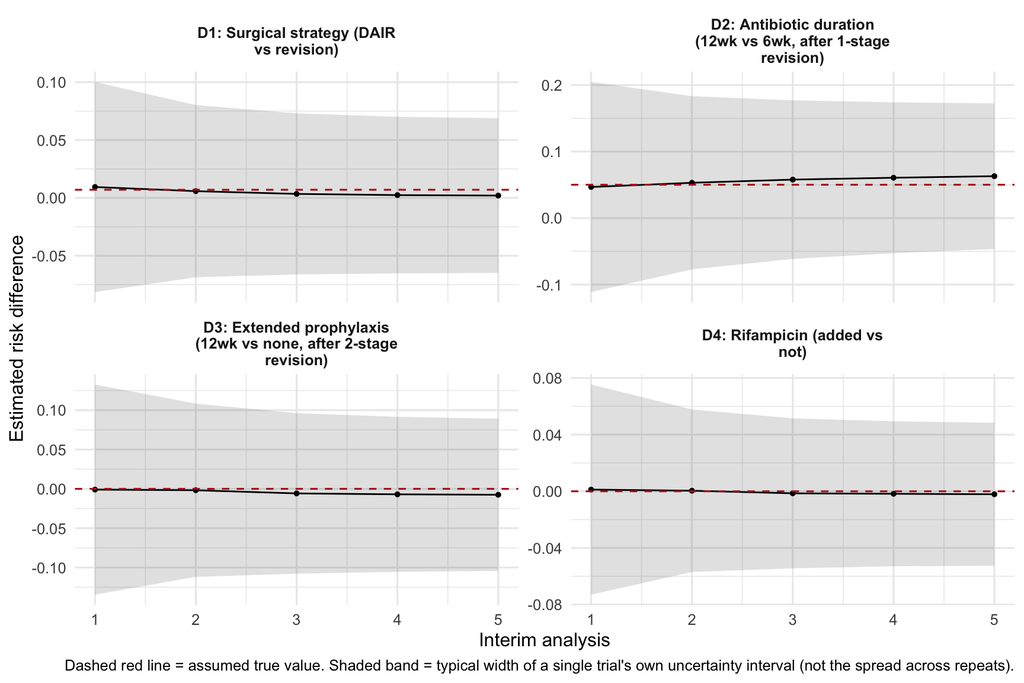

## d3 l-OR = 0.564

**Assumed truth**

**D1: Surgical strategy (DAIR vs revision)** has a true effect of about 2.63 percentage points (risk-difference scale); **D3: Extended prophylaxis (12wk vs none, after 2-stage revision)** has a true effect of about 12.50 percentage points (risk-difference scale). Any remaining question is set to zero.

### Chance of reaching each decision

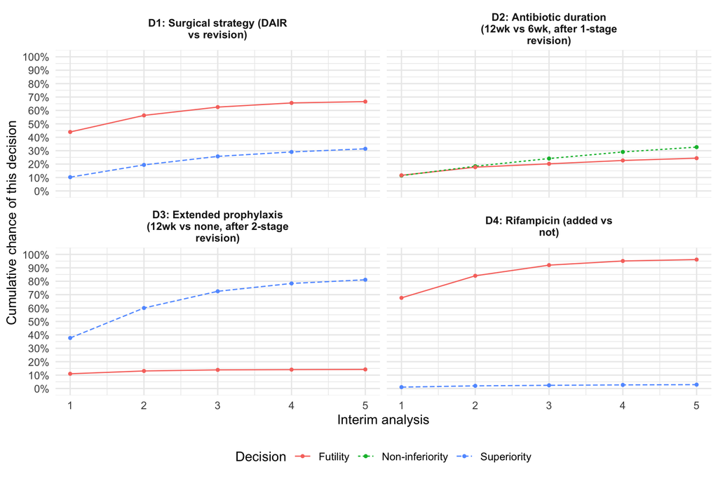

### Typical patient numbers

Patients enrolled by the time a decision is reached

| Domain | Rule | Chance of reaching a decision | Typical no. enrolled at decision | Typical no. informing this decision |
| --- | --- | --- | --- | --- |
| D1: Surgical strategy (DAIR vs revision) | Superiority | 31% | 1155 | 463 |
| D1: Surgical strategy (DAIR vs revision) | Futility | 67% | 786 | 314 |
| D2: Antibiotic duration (12wk vs 6wk, after 1-stage revision) | Non-inferiority | 33% | 1229 | 163 |
| D2: Antibiotic duration (12wk vs 6wk, after 1-stage revision) | Futility | 24% | 1019 | 136 |
| D3: Extended prophylaxis (12wk vs none, after 2-stage revision) | Superiority | 81% | 967 | 187 |
| D3: Extended prophylaxis (12wk vs none, after 2-stage revision) | Futility | 14% | 672 | 132 |
| D4: Rifampicin (added vs not) | Superiority | 3% | 1095 | 768 |
| D4: Rifampicin (added vs not) | Futility | 96% | 738 | 516 |

### Recovered vs. true effect

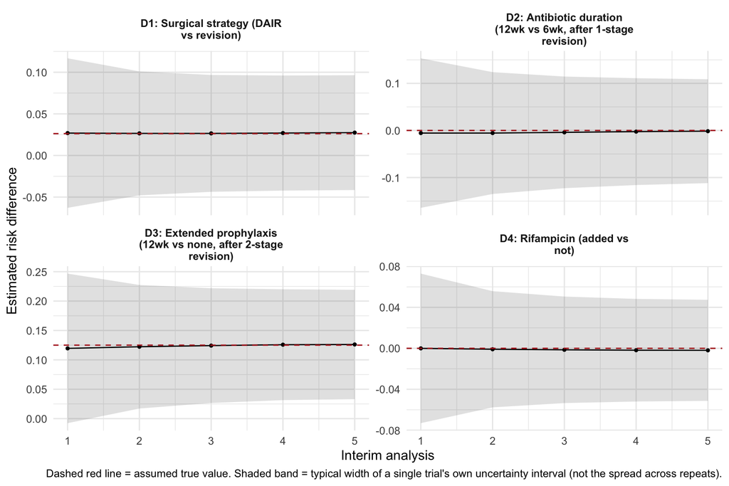

## d3 l-OR = 0.25

**Assumed truth**

**D1: Surgical strategy (DAIR vs revision)** has a true effect of about 1.22 percentage points (risk-difference scale); **D3: Extended prophylaxis (12wk vs none, after 2-stage revision)** has a true effect of about 5.82 percentage points (risk-difference scale). Any remaining question is set to zero.

### Chance of reaching each decision

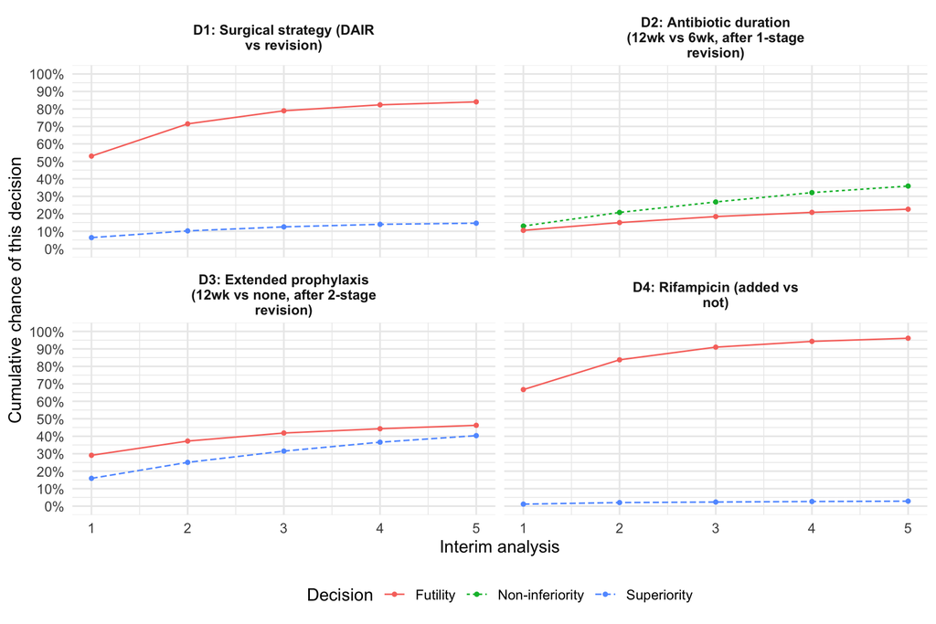

### Typical patient numbers

Patients enrolled by the time a decision is reached

| Domain | Rule | Chance of reaching a decision | Typical no. enrolled at decision | Typical no. informing this decision |
| --- | --- | --- | --- | --- |
| D1: Surgical strategy (DAIR vs revision) | Superiority | 15% | 1027 | 410 |
| D1: Surgical strategy (DAIR vs revision) | Futility | 84% | 800 | 320 |
| D2: Antibiotic duration (12wk vs 6wk, after 1-stage revision) | Non-inferiority | 36% | 1209 | 154 |
| D2: Antibiotic duration (12wk vs 6wk, after 1-stage revision) | Futility | 23% | 1070 | 136 |
| D3: Extended prophylaxis (12wk vs none, after 2-stage revision) | Superiority | 40% | 1149 | 209 |
| D3: Extended prophylaxis (12wk vs none, after 2-stage revision) | Futility | 46% | 851 | 159 |
| D4: Rifampicin (added vs not) | Superiority | 3% | 1061 | 743 |
| D4: Rifampicin (added vs not) | Futility | 96% | 753 | 527 |

### Recovered vs. true effect

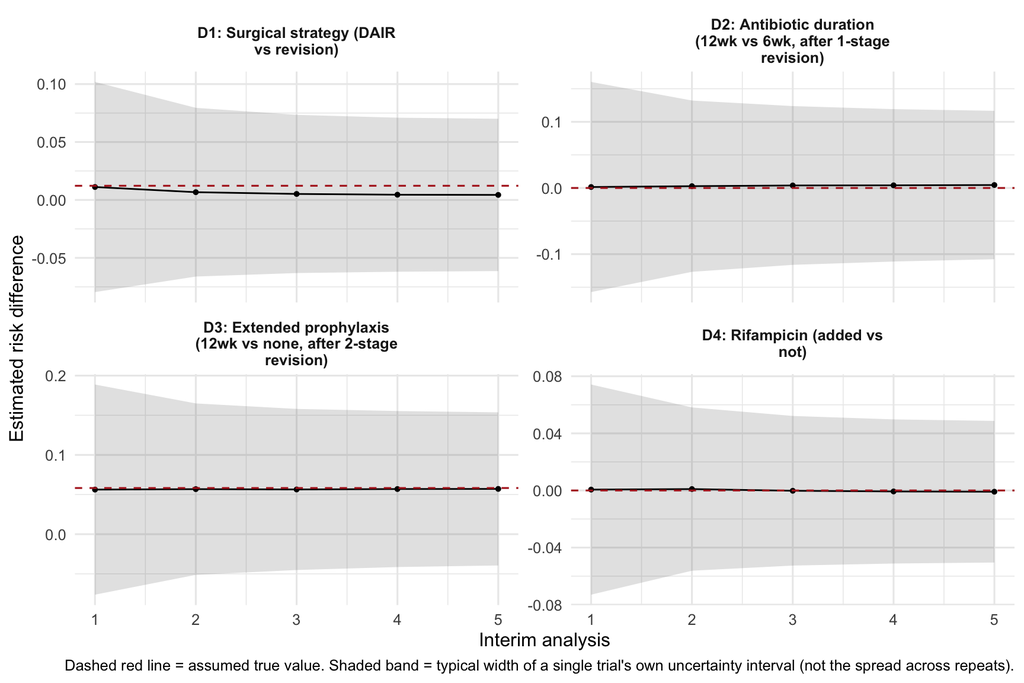

## Mix d2 l-OR = -0.1, d3 l-OR = 0.7, d4 l-OR = 0.3

**Assumed truth**

**D1: Surgical strategy (DAIR vs revision)** has a true effect of about 2.72 percentage points (risk-difference scale); **D2: Antibiotic duration (12wk vs 6wk, after 1-stage revision)** has a true effect of about -2.36 percentage points (risk-difference scale); **D3: Extended prophylaxis (12wk vs none, after 2-stage revision)** has a true effect of about 14.51 percentage points (risk-difference scale); **D4: Rifampicin (added vs not)** has a true effect of about 6.77 percentage points (risk-difference scale). Any remaining question is set to zero.

### Chance of reaching each decision

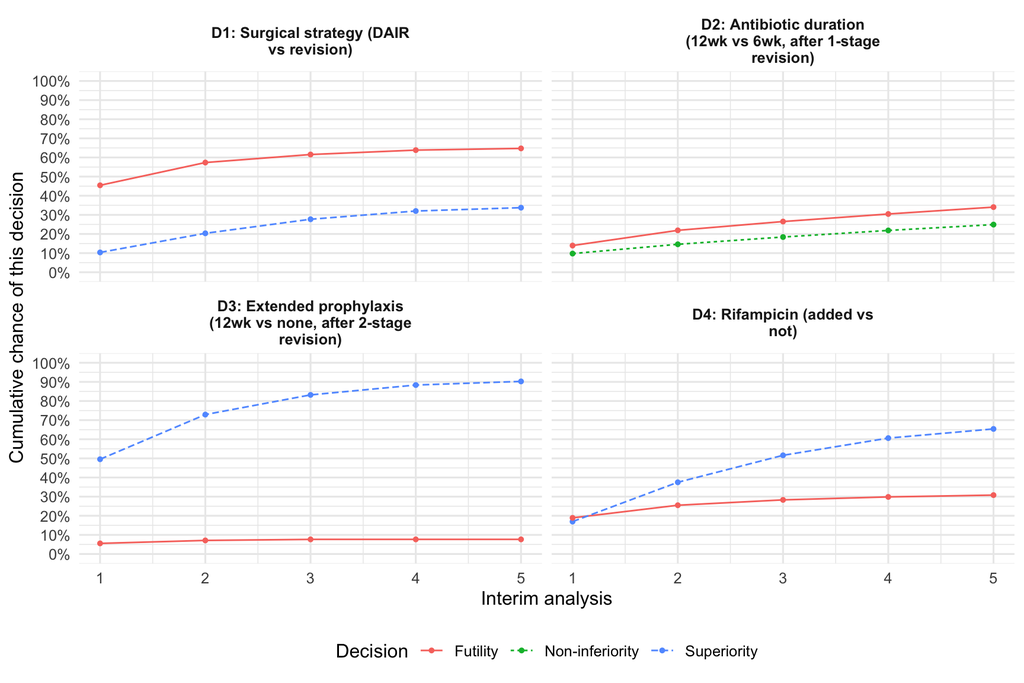

### Typical patient numbers

Patients enrolled by the time a decision is reached

| Domain | Rule | Chance of reaching a decision | Typical no. enrolled at decision | Typical no. informing this decision |
| --- | --- | --- | --- | --- |
| D1: Surgical strategy (DAIR vs revision) | Superiority | 34% | 1161 | 465 |
| D1: Surgical strategy (DAIR vs revision) | Futility | 65% | 738 | 295 |
| D2: Antibiotic duration (12wk vs 6wk, after 1-stage revision) | Non-inferiority | 25% | 1203 | 160 |
| D2: Antibiotic duration (12wk vs 6wk, after 1-stage revision) | Futility | 34% | 1137 | 151 |
| D3: Extended prophylaxis (12wk vs none, after 2-stage revision) | Superiority | 90% | 871 | 168 |
| D3: Extended prophylaxis (12wk vs none, after 2-stage revision) | Futility | 8% | 673 | 132 |
| D4: Rifampicin (added vs not) | Superiority | 65% | 1226 | 858 |
| D4: Rifampicin (added vs not) | Futility | 31% | 835 | 585 |

### Recovered vs. true effect

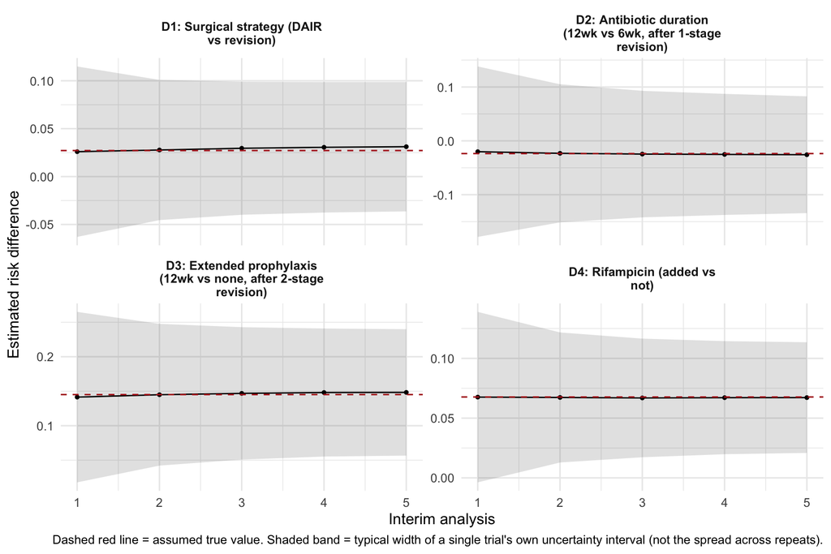

# Appendix

Further detail for readers wanting the numbers behind the plots above: bias, root-mean-square error (RMSE), and coverage of the 95% credible interval, on both the log-odds and risk-difference scales.

Regimen-level weights that are used to build each domain’s contrast are provided.

Coverage is the proportion of trials whose own credible interval contained the assumed true value.

## All domains log OR zero

### Standardised marginal log-odds ratio

| i_anlys | par | truth | mean_est | se_est | sd_est | bias | rmse | coverage |
| --- | --- | --- | --- | --- | --- | --- | --- | --- |
| 1 | d1 | 0.000 | NaN | NA | NA | NaN | NaN | NaN |
| 2 | d1 | 0.000 | NaN | NA | NA | NaN | NaN | NaN |
| 3 | d1 | 0.000 | NaN | NA | NA | NaN | NaN | NaN |
| 4 | d1 | 0.000 | NaN | NA | NA | NaN | NaN | NaN |
| 5 | d1 | 0.000 | NaN | NA | NA | NaN | NaN | NaN |
| 1 | d2 | 0.000 | NaN | NA | NA | NaN | NaN | NaN |
| 2 | d2 | 0.000 | NaN | NA | NA | NaN | NaN | NaN |
| 3 | d2 | 0.000 | NaN | NA | NA | NaN | NaN | NaN |
| 4 | d2 | 0.000 | NaN | NA | NA | NaN | NaN | NaN |
| 5 | d2 | 0.000 | NaN | NA | NA | NaN | NaN | NaN |
| 1 | d3 | 0.000 | NaN | NA | NA | NaN | NaN | NaN |
| 2 | d3 | 0.000 | NaN | NA | NA | NaN | NaN | NaN |
| 3 | d3 | 0.000 | NaN | NA | NA | NaN | NaN | NaN |
| 4 | d3 | 0.000 | NaN | NA | NA | NaN | NaN | NaN |
| 5 | d3 | 0.000 | NaN | NA | NA | NaN | NaN | NaN |
| 1 | d4 | 0.000 | NaN | NA | NA | NaN | NaN | NaN |
| 2 | d4 | 0.000 | NaN | NA | NA | NaN | NaN | NaN |
| 3 | d4 | 0.000 | NaN | NA | NA | NaN | NaN | NaN |
| 4 | d4 | 0.000 | NaN | NA | NA | NaN | NaN | NaN |
| 5 | d4 | 0.000 | NaN | NA | NA | NaN | NaN | NaN |

### Standardised marginal risk difference

| i_anlys | par | truth | mean_est | se_est | sd_est | bias | rmse | coverage |
| --- | --- | --- | --- | --- | --- | --- | --- | --- |
| 1 | d1 | 0.000 | 0.000 | 0.065 | 0.092 | 0.000 | 0.065 | 0.944 |
| 2 | d1 | 0.000 | −0.003 | 0.053 | 0.074 | −0.003 | 0.053 | 0.953 |
| 3 | d1 | 0.000 | −0.005 | 0.049 | 0.069 | −0.005 | 0.049 | 0.948 |
| 4 | d1 | 0.000 | −0.006 | 0.048 | 0.067 | −0.006 | 0.048 | 0.948 |
| 5 | d1 | 0.000 | −0.006 | 0.047 | 0.066 | −0.006 | 0.048 | 0.948 |
| 1 | d2 | 0.000 | −0.001 | 0.115 | 0.160 | −0.001 | 0.115 | 0.942 |
| 2 | d2 | 0.000 | −0.002 | 0.097 | 0.131 | −0.002 | 0.097 | 0.942 |
| 3 | d2 | 0.000 | −0.002 | 0.095 | 0.121 | −0.002 | 0.095 | 0.938 |
| 4 | d2 | 0.000 | −0.002 | 0.094 | 0.116 | −0.002 | 0.094 | 0.938 |
| 5 | d2 | 0.000 | −0.001 | 0.095 | 0.113 | −0.001 | 0.095 | 0.938 |
| 1 | d3 | 0.000 | 0.003 | 0.099 | 0.136 | 0.003 | 0.099 | 0.926 |
| 2 | d3 | 0.000 | 0.001 | 0.080 | 0.111 | 0.001 | 0.080 | 0.934 |
| 3 | d3 | 0.000 | −0.002 | 0.076 | 0.104 | −0.002 | 0.076 | 0.932 |
| 4 | d3 | 0.000 | −0.003 | 0.074 | 0.100 | −0.003 | 0.075 | 0.925 |
| 5 | d3 | 0.000 | −0.005 | 0.073 | 0.098 | −0.005 | 0.073 | 0.933 |
| 1 | d4 | 0.000 | 0.001 | 0.052 | 0.073 | 0.001 | 0.052 | 0.944 |
| 2 | d4 | 0.000 | 0.001 | 0.040 | 0.057 | 0.001 | 0.040 | 0.953 |
| 3 | d4 | 0.000 | 0.000 | 0.037 | 0.053 | 0.000 | 0.037 | 0.953 |
| 4 | d4 | 0.000 | 0.000 | 0.036 | 0.052 | 0.000 | 0.036 | 0.951 |
| 5 | d4 | 0.000 | −0.001 | 0.036 | 0.051 | −0.001 | 0.036 | 0.952 |

### Regimen weights by interim (mean, sd)

d1 regimen weights

| side | reg | 1 | 2 | 3 | 4 | 5 |
| --- | --- | --- | --- | --- | --- | --- |
| rev | l_r1_nad2_nad3 | 0.120 (0.033) | 0.120 (0.029) | 0.120 (0.028) | 0.120 (0.028) | 0.119 (0.028) |
| rev | l_r1_wk12_nad3 | 0.142 (0.034) | 0.139 (0.038) | 0.139 (0.039) | 0.138 (0.037) | 0.138 (0.036) |
| rev | l_r1_wk6_nad3 | 0.138 (0.035) | 0.139 (0.038) | 0.139 (0.038) | 0.138 (0.038) | 0.138 (0.036) |
| rev | l_r2_nad2_nad3 | 0.182 (0.038) | 0.182 (0.034) | 0.183 (0.033) | 0.182 (0.033) | 0.183 (0.032) |
| rev | l_r2_nad2_none | 0.208 (0.042) | 0.229 (0.064) | 0.235 (0.074) | 0.239 (0.080) | 0.240 (0.083) |
| rev | l_r2_nad2_wk12 | 0.209 (0.042) | 0.191 (0.061) | 0.185 (0.071) | 0.183 (0.075) | 0.182 (0.077) |

d2 regimen weights

| side | reg | 1 | 2 | 3 | 4 | 5 |
| --- | --- | --- | --- | --- | --- | --- |
| wk12 | cnrd1_r1_wk12_nad3 | 0.293 (0.043) | 0.331 (0.050) | 0.356 (0.058) | 0.375 (0.061) | 0.387 (0.063) |
| wk12 | enrd1_r1_wk12_nad3 | 0.220 (0.042) | 0.250 (0.044) | 0.267 (0.047) | 0.281 (0.049) | 0.291 (0.050) |
| wk12 | l_r1_wk12_nad3 | 0.390 (0.048) | 0.308 (0.084) | 0.259 (0.107) | 0.221 (0.116) | 0.194 (0.122) |
| wk12 | lnrd1_r1_wk12_nad3 | 0.097 (0.029) | 0.111 (0.026) | 0.118 (0.026) | 0.124 (0.026) | 0.128 (0.026) |
| wk6 | cnrd1_r1_wk6_nad3 | 0.293 (0.043) | 0.331 (0.050) | 0.356 (0.058) | 0.375 (0.061) | 0.387 (0.063) |
| wk6 | enrd1_r1_wk6_nad3 | 0.220 (0.042) | 0.250 (0.044) | 0.267 (0.047) | 0.281 (0.049) | 0.291 (0.050) |
| wk6 | l_r1_wk6_nad3 | 0.390 (0.048) | 0.308 (0.084) | 0.259 (0.107) | 0.221 (0.116) | 0.194 (0.122) |
| wk6 | lnrd1_r1_wk6_nad3 | 0.097 (0.029) | 0.111 (0.026) | 0.118 (0.026) | 0.124 (0.026) | 0.128 (0.026) |

d3 regimen weights

| side | reg | 1 | 2 | 3 | 4 | 5 |
| --- | --- | --- | --- | --- | --- | --- |
| none | cnrd1_r2_nad2_none | 0.339 (0.039) | 0.386 (0.057) | 0.414 (0.070) | 0.436 (0.076) | 0.453 (0.080) |
| none | enrd1_r2_nad2_none | 0.152 (0.029) | 0.172 (0.032) | 0.186 (0.036) | 0.196 (0.037) | 0.203 (0.038) |
| none | l_r2_nad2_none | 0.407 (0.040) | 0.326 (0.090) | 0.275 (0.117) | 0.237 (0.128) | 0.208 (0.136) |
| none | lnrd1_r2_nad2_none | 0.102 (0.025) | 0.116 (0.025) | 0.124 (0.026) | 0.131 (0.027) | 0.136 (0.028) |
| wk12 | cnrd1_r2_nad2_wk12 | 0.339 (0.039) | 0.386 (0.057) | 0.414 (0.070) | 0.436 (0.076) | 0.453 (0.080) |
| wk12 | enrd1_r2_nad2_wk12 | 0.152 (0.029) | 0.172 (0.032) | 0.186 (0.036) | 0.196 (0.037) | 0.203 (0.038) |
| wk12 | l_r2_nad2_wk12 | 0.407 (0.040) | 0.326 (0.090) | 0.275 (0.117) | 0.237 (0.128) | 0.208 (0.136) |
| wk12 | lnrd1_r2_nad2_wk12 | 0.102 (0.025) | 0.116 (0.025) | 0.124 (0.026) | 0.131 (0.027) | 0.136 (0.028) |

## d1 l-OR = 0.5

### Standardised marginal log-odds ratio

| i_anlys | par | truth | mean_est | se_est | sd_est | bias | rmse | coverage |
| --- | --- | --- | --- | --- | --- | --- | --- | --- |
| 1 | d1 | 0.500 | NaN | NA | NA | NaN | NaN | NaN |
| 2 | d1 | 0.500 | NaN | NA | NA | NaN | NaN | NaN |
| 3 | d1 | 0.500 | NaN | NA | NA | NaN | NaN | NaN |
| 4 | d1 | 0.500 | NaN | NA | NA | NaN | NaN | NaN |
| 5 | d1 | 0.500 | NaN | NA | NA | NaN | NaN | NaN |
| 1 | d2 | 0.000 | NaN | NA | NA | NaN | NaN | NaN |
| 2 | d2 | 0.000 | NaN | NA | NA | NaN | NaN | NaN |
| 3 | d2 | 0.000 | NaN | NA | NA | NaN | NaN | NaN |
| 4 | d2 | 0.000 | NaN | NA | NA | NaN | NaN | NaN |
| 5 | d2 | 0.000 | NaN | NA | NA | NaN | NaN | NaN |
| 1 | d3 | 0.000 | NaN | NA | NA | NaN | NaN | NaN |
| 2 | d3 | 0.000 | NaN | NA | NA | NaN | NaN | NaN |
| 3 | d3 | 0.000 | NaN | NA | NA | NaN | NaN | NaN |
| 4 | d3 | 0.000 | NaN | NA | NA | NaN | NaN | NaN |
| 5 | d3 | 0.000 | NaN | NA | NA | NaN | NaN | NaN |
| 1 | d4 | 0.000 | NaN | NA | NA | NaN | NaN | NaN |
| 2 | d4 | 0.000 | NaN | NA | NA | NaN | NaN | NaN |
| 3 | d4 | 0.000 | NaN | NA | NA | NaN | NaN | NaN |
| 4 | d4 | 0.000 | NaN | NA | NA | NaN | NaN | NaN |
| 5 | d4 | 0.000 | NaN | NA | NA | NaN | NaN | NaN |

### Standardised marginal risk difference

| i_anlys | par | truth | mean_est | se_est | sd_est | bias | rmse | coverage |
| --- | --- | --- | --- | --- | --- | --- | --- | --- |
| 1 | d1 | 0.112 | 0.107 | 0.061 | 0.087 | −0.005 | 0.061 | 0.953 |
| 2 | d1 | 0.112 | 0.110 | 0.050 | 0.071 | −0.002 | 0.051 | 0.951 |
| 3 | d1 | 0.112 | 0.113 | 0.047 | 0.066 | 0.001 | 0.047 | 0.946 |
| 4 | d1 | 0.112 | 0.114 | 0.045 | 0.064 | 0.002 | 0.046 | 0.950 |
| 5 | d1 | 0.112 | 0.114 | 0.045 | 0.063 | 0.002 | 0.045 | 0.952 |
| 1 | d2 | 0.000 | 0.000 | 0.112 | 0.155 | 0.000 | 0.112 | 0.935 |
| 2 | d2 | 0.000 | 0.000 | 0.093 | 0.123 | 0.000 | 0.093 | 0.932 |
| 3 | d2 | 0.000 | 0.000 | 0.092 | 0.113 | 0.000 | 0.092 | 0.925 |
| 4 | d2 | 0.000 | 0.001 | 0.091 | 0.108 | 0.001 | 0.091 | 0.923 |
| 5 | d2 | 0.000 | 0.001 | 0.091 | 0.104 | 0.001 | 0.091 | 0.921 |
| 1 | d3 | 0.000 | 0.002 | 0.092 | 0.129 | 0.002 | 0.092 | 0.936 |
| 2 | d3 | 0.000 | −0.003 | 0.071 | 0.100 | −0.003 | 0.071 | 0.951 |
| 3 | d3 | 0.000 | −0.006 | 0.067 | 0.092 | −0.006 | 0.067 | 0.942 |
| 4 | d3 | 0.000 | −0.007 | 0.065 | 0.089 | −0.007 | 0.066 | 0.946 |
| 5 | d3 | 0.000 | −0.008 | 0.064 | 0.087 | −0.008 | 0.065 | 0.941 |
| 1 | d4 | 0.000 | −0.002 | 0.052 | 0.072 | −0.002 | 0.052 | 0.943 |
| 2 | d4 | 0.000 | −0.001 | 0.039 | 0.056 | −0.001 | 0.039 | 0.951 |
| 3 | d4 | 0.000 | −0.002 | 0.036 | 0.052 | −0.002 | 0.036 | 0.957 |
| 4 | d4 | 0.000 | −0.003 | 0.035 | 0.050 | −0.003 | 0.035 | 0.961 |
| 5 | d4 | 0.000 | −0.003 | 0.034 | 0.049 | −0.003 | 0.034 | 0.959 |

### Regimen weights by interim (mean, sd)

d1 regimen weights

| side | reg | 1 | 2 | 3 | 4 | 5 |
| --- | --- | --- | --- | --- | --- | --- |
| rev | l_r1_nad2_nad3 | 0.119 (0.033) | 0.112 (0.022) | 0.109 (0.019) | 0.107 (0.017) | 0.106 (0.016) |
| rev | l_r1_wk12_nad3 | 0.139 (0.036) | 0.131 (0.040) | 0.126 (0.039) | 0.124 (0.036) | 0.123 (0.031) |
| rev | l_r1_wk6_nad3 | 0.140 (0.035) | 0.133 (0.040) | 0.130 (0.040) | 0.127 (0.036) | 0.125 (0.031) |
| rev | l_r2_nad2_nad3 | 0.182 (0.039) | 0.187 (0.026) | 0.191 (0.022) | 0.193 (0.020) | 0.194 (0.019) |
| rev | l_r2_nad2_none | 0.209 (0.041) | 0.269 (0.086) | 0.297 (0.104) | 0.317 (0.114) | 0.332 (0.120) |
| rev | l_r2_nad2_wk12 | 0.211 (0.042) | 0.168 (0.083) | 0.147 (0.101) | 0.132 (0.112) | 0.121 (0.117) |

d2 regimen weights

| side | reg | 1 | 2 | 3 | 4 | 5 |
| --- | --- | --- | --- | --- | --- | --- |
| wk12 | cnrd1_r1_wk12_nad3 | 0.293 (0.046) | 0.279 (0.043) | 0.274 (0.048) | 0.270 (0.052) | 0.269 (0.058) |
| wk12 | enrd1_r1_wk12_nad3 | 0.221 (0.042) | 0.211 (0.035) | 0.207 (0.038) | 0.204 (0.040) | 0.202 (0.043) |
| wk12 | l_r1_wk12_nad3 | 0.389 (0.049) | 0.416 (0.068) | 0.428 (0.088) | 0.436 (0.102) | 0.439 (0.115) |
| wk12 | lnrd1_r1_wk12_nad3 | 0.098 (0.030) | 0.094 (0.022) | 0.091 (0.021) | 0.090 (0.022) | 0.090 (0.022) |
| wk6 | cnrd1_r1_wk6_nad3 | 0.293 (0.046) | 0.279 (0.043) | 0.274 (0.048) | 0.270 (0.052) | 0.269 (0.058) |
| wk6 | enrd1_r1_wk6_nad3 | 0.221 (0.042) | 0.211 (0.035) | 0.207 (0.038) | 0.204 (0.040) | 0.202 (0.043) |
| wk6 | l_r1_wk6_nad3 | 0.389 (0.049) | 0.416 (0.068) | 0.428 (0.088) | 0.436 (0.102) | 0.439 (0.115) |
| wk6 | lnrd1_r1_wk6_nad3 | 0.098 (0.030) | 0.094 (0.022) | 0.091 (0.021) | 0.090 (0.022) | 0.090 (0.022) |

d3 regimen weights

| side | reg | 1 | 2 | 3 | 4 | 5 |
| --- | --- | --- | --- | --- | --- | --- |
| none | cnrd1_r2_nad2_none | 0.338 (0.040) | 0.310 (0.052) | 0.296 (0.064) | 0.287 (0.071) | 0.283 (0.080) |
| none | enrd1_r2_nad2_none | 0.153 (0.030) | 0.140 (0.028) | 0.134 (0.031) | 0.129 (0.035) | 0.127 (0.037) |
| none | l_r2_nad2_none | 0.408 (0.041) | 0.458 (0.084) | 0.482 (0.108) | 0.498 (0.124) | 0.505 (0.139) |
| none | lnrd1_r2_nad2_none | 0.101 (0.024) | 0.092 (0.021) | 0.088 (0.022) | 0.086 (0.024) | 0.084 (0.025) |
| wk12 | cnrd1_r2_nad2_wk12 | 0.338 (0.040) | 0.310 (0.052) | 0.296 (0.064) | 0.287 (0.071) | 0.283 (0.080) |
| wk12 | enrd1_r2_nad2_wk12 | 0.153 (0.030) | 0.140 (0.028) | 0.134 (0.031) | 0.129 (0.035) | 0.127 (0.037) |
| wk12 | l_r2_nad2_wk12 | 0.408 (0.041) | 0.458 (0.084) | 0.482 (0.108) | 0.498 (0.124) | 0.505 (0.139) |
| wk12 | lnrd1_r2_nad2_wk12 | 0.101 (0.024) | 0.092 (0.021) | 0.088 (0.022) | 0.086 (0.024) | 0.084 (0.025) |

## d1 l-OR = 0.3

### Standardised marginal log-odds ratio

| i_anlys | par | truth | mean_est | se_est | sd_est | bias | rmse | coverage |
| --- | --- | --- | --- | --- | --- | --- | --- | --- |
| 1 | d1 | 0.300 | NaN | NA | NA | NaN | NaN | NaN |
| 2 | d1 | 0.300 | NaN | NA | NA | NaN | NaN | NaN |
| 3 | d1 | 0.300 | NaN | NA | NA | NaN | NaN | NaN |
| 4 | d1 | 0.300 | NaN | NA | NA | NaN | NaN | NaN |
| 5 | d1 | 0.300 | NaN | NA | NA | NaN | NaN | NaN |
| 1 | d2 | 0.000 | NaN | NA | NA | NaN | NaN | NaN |
| 2 | d2 | 0.000 | NaN | NA | NA | NaN | NaN | NaN |
| 3 | d2 | 0.000 | NaN | NA | NA | NaN | NaN | NaN |
| 4 | d2 | 0.000 | NaN | NA | NA | NaN | NaN | NaN |
| 5 | d2 | 0.000 | NaN | NA | NA | NaN | NaN | NaN |
| 1 | d3 | 0.000 | NaN | NA | NA | NaN | NaN | NaN |
| 2 | d3 | 0.000 | NaN | NA | NA | NaN | NaN | NaN |
| 3 | d3 | 0.000 | NaN | NA | NA | NaN | NaN | NaN |
| 4 | d3 | 0.000 | NaN | NA | NA | NaN | NaN | NaN |
| 5 | d3 | 0.000 | NaN | NA | NA | NaN | NaN | NaN |
| 1 | d4 | 0.000 | NaN | NA | NA | NaN | NaN | NaN |
| 2 | d4 | 0.000 | NaN | NA | NA | NaN | NaN | NaN |
| 3 | d4 | 0.000 | NaN | NA | NA | NaN | NaN | NaN |
| 4 | d4 | 0.000 | NaN | NA | NA | NaN | NaN | NaN |
| 5 | d4 | 0.000 | NaN | NA | NA | NaN | NaN | NaN |

### Standardised marginal risk difference

| i_anlys | par | truth | mean_est | se_est | sd_est | bias | rmse | coverage |
| --- | --- | --- | --- | --- | --- | --- | --- | --- |
| 1 | d1 | 0.069 | 0.066 | 0.062 | 0.089 | −0.003 | 0.062 | 0.953 |
| 2 | d1 | 0.069 | 0.067 | 0.053 | 0.073 | −0.003 | 0.053 | 0.950 |
| 3 | d1 | 0.069 | 0.068 | 0.051 | 0.068 | −0.002 | 0.051 | 0.940 |
| 4 | d1 | 0.069 | 0.068 | 0.050 | 0.066 | −0.001 | 0.050 | 0.943 |
| 5 | d1 | 0.069 | 0.069 | 0.050 | 0.065 | −0.001 | 0.050 | 0.946 |
| 1 | d2 | 0.000 | 0.001 | 0.114 | 0.158 | 0.001 | 0.114 | 0.936 |
| 2 | d2 | 0.000 | 0.003 | 0.095 | 0.125 | 0.003 | 0.095 | 0.934 |
| 3 | d2 | 0.000 | 0.004 | 0.090 | 0.115 | 0.004 | 0.090 | 0.938 |
| 4 | d2 | 0.000 | 0.005 | 0.090 | 0.110 | 0.005 | 0.090 | 0.933 |
| 5 | d2 | 0.000 | 0.006 | 0.090 | 0.106 | 0.006 | 0.091 | 0.935 |
| 1 | d3 | 0.000 | 0.003 | 0.095 | 0.132 | 0.003 | 0.095 | 0.941 |
| 2 | d3 | 0.000 | −0.002 | 0.077 | 0.106 | −0.002 | 0.077 | 0.932 |
| 3 | d3 | 0.000 | −0.005 | 0.072 | 0.098 | −0.005 | 0.072 | 0.933 |
| 4 | d3 | 0.000 | −0.007 | 0.070 | 0.094 | −0.007 | 0.070 | 0.942 |
| 5 | d3 | 0.000 | −0.008 | 0.069 | 0.092 | −0.008 | 0.069 | 0.939 |
| 1 | d4 | 0.000 | 0.001 | 0.053 | 0.074 | 0.001 | 0.053 | 0.941 |
| 2 | d4 | 0.000 | 0.001 | 0.040 | 0.057 | 0.001 | 0.040 | 0.950 |
| 3 | d4 | 0.000 | 0.000 | 0.036 | 0.052 | 0.000 | 0.036 | 0.957 |
| 4 | d4 | 0.000 | −0.001 | 0.034 | 0.050 | −0.001 | 0.034 | 0.960 |
| 5 | d4 | 0.000 | −0.001 | 0.034 | 0.049 | −0.001 | 0.034 | 0.961 |

### Regimen weights by interim (mean, sd)

d1 regimen weights

| side | reg | 1 | 2 | 3 | 4 | 5 |
| --- | --- | --- | --- | --- | --- | --- |
| rev | l_r1_nad2_nad3 | 0.120 (0.033) | 0.117 (0.025) | 0.115 (0.022) | 0.113 (0.021) | 0.112 (0.021) |
| rev | l_r1_wk12_nad3 | 0.141 (0.035) | 0.135 (0.040) | 0.131 (0.044) | 0.128 (0.042) | 0.129 (0.036) |
| rev | l_r1_wk6_nad3 | 0.139 (0.035) | 0.137 (0.040) | 0.135 (0.043) | 0.134 (0.042) | 0.131 (0.036) |
| rev | l_r2_nad2_nad3 | 0.179 (0.038) | 0.183 (0.029) | 0.186 (0.026) | 0.188 (0.025) | 0.190 (0.025) |
| rev | l_r2_nad2_none | 0.211 (0.040) | 0.254 (0.076) | 0.276 (0.094) | 0.289 (0.104) | 0.295 (0.113) |
| rev | l_r2_nad2_wk12 | 0.211 (0.041) | 0.174 (0.072) | 0.157 (0.090) | 0.148 (0.099) | 0.143 (0.106) |

d2 regimen weights

| side | reg | 1 | 2 | 3 | 4 | 5 |
| --- | --- | --- | --- | --- | --- | --- |
| wk12 | cnrd1_r1_wk12_nad3 | 0.294 (0.046) | 0.299 (0.050) | 0.302 (0.060) | 0.306 (0.070) | 0.311 (0.078) |
| wk12 | enrd1_r1_wk12_nad3 | 0.219 (0.041) | 0.223 (0.039) | 0.226 (0.045) | 0.229 (0.052) | 0.232 (0.058) |
| wk12 | l_r1_wk12_nad3 | 0.390 (0.049) | 0.379 (0.082) | 0.372 (0.112) | 0.363 (0.135) | 0.354 (0.155) |
| wk12 | lnrd1_r1_wk12_nad3 | 0.098 (0.029) | 0.099 (0.023) | 0.100 (0.024) | 0.102 (0.025) | 0.103 (0.028) |
| wk6 | cnrd1_r1_wk6_nad3 | 0.294 (0.046) | 0.299 (0.050) | 0.302 (0.060) | 0.306 (0.070) | 0.311 (0.078) |
| wk6 | enrd1_r1_wk6_nad3 | 0.219 (0.041) | 0.223 (0.039) | 0.226 (0.045) | 0.229 (0.052) | 0.232 (0.058) |
| wk6 | l_r1_wk6_nad3 | 0.390 (0.049) | 0.379 (0.082) | 0.372 (0.112) | 0.363 (0.135) | 0.354 (0.155) |
| wk6 | lnrd1_r1_wk6_nad3 | 0.098 (0.029) | 0.099 (0.023) | 0.100 (0.024) | 0.102 (0.025) | 0.103 (0.028) |

d3 regimen weights

| side | reg | 1 | 2 | 3 | 4 | 5 |
| --- | --- | --- | --- | --- | --- | --- |
| none | cnrd1_r2_nad2_none | 0.338 (0.040) | 0.338 (0.056) | 0.338 (0.076) | 0.341 (0.092) | 0.344 (0.105) |
| none | enrd1_r2_nad2_none | 0.153 (0.030) | 0.154 (0.032) | 0.153 (0.038) | 0.153 (0.043) | 0.155 (0.048) |
| none | l_r2_nad2_none | 0.408 (0.042) | 0.407 (0.092) | 0.408 (0.129) | 0.404 (0.158) | 0.398 (0.181) |
| none | lnrd1_r2_nad2_none | 0.101 (0.025) | 0.101 (0.023) | 0.101 (0.026) | 0.102 (0.029) | 0.103 (0.033) |
| wk12 | cnrd1_r2_nad2_wk12 | 0.338 (0.040) | 0.338 (0.056) | 0.338 (0.076) | 0.341 (0.092) | 0.344 (0.105) |
| wk12 | enrd1_r2_nad2_wk12 | 0.153 (0.030) | 0.154 (0.032) | 0.153 (0.038) | 0.153 (0.043) | 0.155 (0.048) |
| wk12 | l_r2_nad2_wk12 | 0.408 (0.042) | 0.407 (0.092) | 0.408 (0.129) | 0.404 (0.158) | 0.398 (0.181) |
| wk12 | lnrd1_r2_nad2_wk12 | 0.101 (0.025) | 0.101 (0.023) | 0.101 (0.026) | 0.102 (0.029) | 0.103 (0.033) |

## d4 l-OR = 0.5

### Standardised marginal log-odds ratio

| i_anlys | par | truth | mean_est | se_est | sd_est | bias | rmse | coverage |
| --- | --- | --- | --- | --- | --- | --- | --- | --- |
| 1 | d1 | 0.000 | NaN | NA | NA | NaN | NaN | NaN |
| 2 | d1 | 0.000 | NaN | NA | NA | NaN | NaN | NaN |
| 3 | d1 | 0.000 | NaN | NA | NA | NaN | NaN | NaN |
| 4 | d1 | 0.000 | NaN | NA | NA | NaN | NaN | NaN |
| 5 | d1 | 0.000 | NaN | NA | NA | NaN | NaN | NaN |
| 1 | d2 | 0.000 | NaN | NA | NA | NaN | NaN | NaN |
| 2 | d2 | 0.000 | NaN | NA | NA | NaN | NaN | NaN |
| 3 | d2 | 0.000 | NaN | NA | NA | NaN | NaN | NaN |
| 4 | d2 | 0.000 | NaN | NA | NA | NaN | NaN | NaN |
| 5 | d2 | 0.000 | NaN | NA | NA | NaN | NaN | NaN |
| 1 | d3 | 0.000 | NaN | NA | NA | NaN | NaN | NaN |
| 2 | d3 | 0.000 | NaN | NA | NA | NaN | NaN | NaN |
| 3 | d3 | 0.000 | NaN | NA | NA | NaN | NaN | NaN |
| 4 | d3 | 0.000 | NaN | NA | NA | NaN | NaN | NaN |
| 5 | d3 | 0.000 | NaN | NA | NA | NaN | NaN | NaN |
| 1 | d4 | 0.500 | NaN | NA | NA | NaN | NaN | NaN |
| 2 | d4 | 0.500 | NaN | NA | NA | NaN | NaN | NaN |
| 3 | d4 | 0.500 | NaN | NA | NA | NaN | NaN | NaN |
| 4 | d4 | 0.500 | NaN | NA | NA | NaN | NaN | NaN |
| 5 | d4 | 0.500 | NaN | NA | NA | NaN | NaN | NaN |

### Standardised marginal risk difference

| i_anlys | par | truth | mean_est | se_est | sd_est | bias | rmse | coverage |
| --- | --- | --- | --- | --- | --- | --- | --- | --- |
| 1 | d1 | 0.000 | 0.001 | 0.064 | 0.090 | 0.001 | 0.064 | 0.944 |
| 2 | d1 | 0.000 | −0.003 | 0.052 | 0.072 | −0.003 | 0.052 | 0.947 |
| 3 | d1 | 0.000 | −0.004 | 0.048 | 0.067 | −0.004 | 0.048 | 0.946 |
| 4 | d1 | 0.000 | −0.005 | 0.047 | 0.065 | −0.005 | 0.047 | 0.941 |
| 5 | d1 | 0.000 | −0.005 | 0.046 | 0.064 | −0.005 | 0.046 | 0.946 |
| 1 | d2 | 0.000 | 0.001 | 0.110 | 0.153 | 0.001 | 0.110 | 0.942 |
| 2 | d2 | 0.000 | 0.000 | 0.091 | 0.125 | 0.000 | 0.091 | 0.946 |
| 3 | d2 | 0.000 | 0.002 | 0.088 | 0.115 | 0.002 | 0.088 | 0.941 |
| 4 | d2 | 0.000 | 0.002 | 0.088 | 0.110 | 0.002 | 0.088 | 0.942 |
| 5 | d2 | 0.000 | 0.004 | 0.088 | 0.106 | 0.004 | 0.088 | 0.943 |
| 1 | d3 | 0.000 | 0.001 | 0.093 | 0.130 | 0.001 | 0.093 | 0.948 |
| 2 | d3 | 0.000 | 0.000 | 0.077 | 0.107 | 0.000 | 0.077 | 0.943 |
| 3 | d3 | 0.000 | −0.002 | 0.072 | 0.099 | −0.002 | 0.072 | 0.945 |
| 4 | d3 | 0.000 | −0.004 | 0.070 | 0.095 | −0.004 | 0.070 | 0.945 |
| 5 | d3 | 0.000 | −0.005 | 0.068 | 0.092 | −0.005 | 0.068 | 0.943 |
| 1 | d4 | 0.112 | 0.113 | 0.051 | 0.071 | 0.001 | 0.051 | 0.944 |
| 2 | d4 | 0.112 | 0.115 | 0.040 | 0.056 | 0.002 | 0.040 | 0.945 |
| 3 | d4 | 0.112 | 0.115 | 0.037 | 0.052 | 0.003 | 0.037 | 0.947 |
| 4 | d4 | 0.112 | 0.116 | 0.036 | 0.050 | 0.004 | 0.036 | 0.944 |
| 5 | d4 | 0.112 | 0.116 | 0.036 | 0.050 | 0.004 | 0.036 | 0.947 |

### Regimen weights by interim (mean, sd)

d1 regimen weights

| side | reg | 1 | 2 | 3 | 4 | 5 |
| --- | --- | --- | --- | --- | --- | --- |
| rev | l_r1_nad2_nad3 | 0.121 (0.033) | 0.120 (0.030) | 0.119 (0.029) | 0.119 (0.029) | 0.119 (0.029) |
| rev | l_r1_wk12_nad3 | 0.139 (0.035) | 0.138 (0.038) | 0.137 (0.038) | 0.138 (0.038) | 0.138 (0.036) |
| rev | l_r1_wk6_nad3 | 0.141 (0.035) | 0.141 (0.038) | 0.142 (0.039) | 0.141 (0.037) | 0.141 (0.036) |
| rev | l_r2_nad2_nad3 | 0.180 (0.038) | 0.180 (0.034) | 0.180 (0.033) | 0.180 (0.033) | 0.180 (0.033) |
| rev | l_r2_nad2_none | 0.210 (0.042) | 0.231 (0.062) | 0.238 (0.071) | 0.239 (0.076) | 0.239 (0.077) |
| rev | l_r2_nad2_wk12 | 0.209 (0.041) | 0.191 (0.060) | 0.184 (0.068) | 0.183 (0.071) | 0.182 (0.071) |

d2 regimen weights

| side | reg | 1 | 2 | 3 | 4 | 5 |
| --- | --- | --- | --- | --- | --- | --- |
| wk12 | cnrd1_r1_wk12_nad3 | 0.292 (0.045) | 0.333 (0.052) | 0.357 (0.059) | 0.374 (0.062) | 0.388 (0.062) |
| wk12 | enrd1_r1_wk12_nad3 | 0.218 (0.042) | 0.248 (0.043) | 0.267 (0.047) | 0.281 (0.049) | 0.291 (0.049) |
| wk12 | l_r1_wk12_nad3 | 0.393 (0.049) | 0.309 (0.086) | 0.258 (0.108) | 0.221 (0.118) | 0.192 (0.120) |
| wk12 | lnrd1_r1_wk12_nad3 | 0.097 (0.029) | 0.110 (0.027) | 0.118 (0.027) | 0.124 (0.027) | 0.129 (0.026) |
| wk6 | cnrd1_r1_wk6_nad3 | 0.292 (0.045) | 0.333 (0.052) | 0.357 (0.059) | 0.374 (0.062) | 0.388 (0.062) |
| wk6 | enrd1_r1_wk6_nad3 | 0.218 (0.042) | 0.248 (0.043) | 0.267 (0.047) | 0.281 (0.049) | 0.291 (0.049) |
| wk6 | l_r1_wk6_nad3 | 0.393 (0.049) | 0.309 (0.086) | 0.258 (0.108) | 0.221 (0.118) | 0.192 (0.120) |
| wk6 | lnrd1_r1_wk6_nad3 | 0.097 (0.029) | 0.110 (0.027) | 0.118 (0.027) | 0.124 (0.027) | 0.129 (0.026) |

d3 regimen weights

| side | reg | 1 | 2 | 3 | 4 | 5 |
| --- | --- | --- | --- | --- | --- | --- |
| none | cnrd1_r2_nad2_none | 0.338 (0.039) | 0.385 (0.058) | 0.415 (0.072) | 0.437 (0.078) | 0.454 (0.081) |
| none | enrd1_r2_nad2_none | 0.152 (0.029) | 0.173 (0.032) | 0.187 (0.036) | 0.196 (0.038) | 0.204 (0.039) |
| none | l_r2_nad2_none | 0.408 (0.041) | 0.325 (0.091) | 0.273 (0.118) | 0.236 (0.132) | 0.205 (0.137) |
| none | lnrd1_r2_nad2_none | 0.102 (0.025) | 0.116 (0.025) | 0.125 (0.026) | 0.131 (0.027) | 0.137 (0.028) |
| wk12 | cnrd1_r2_nad2_wk12 | 0.338 (0.039) | 0.385 (0.058) | 0.415 (0.072) | 0.437 (0.078) | 0.454 (0.081) |
| wk12 | enrd1_r2_nad2_wk12 | 0.152 (0.029) | 0.173 (0.032) | 0.187 (0.036) | 0.196 (0.038) | 0.204 (0.039) |
| wk12 | l_r2_nad2_wk12 | 0.408 (0.041) | 0.325 (0.091) | 0.273 (0.118) | 0.236 (0.132) | 0.205 (0.137) |
| wk12 | lnrd1_r2_nad2_wk12 | 0.102 (0.025) | 0.116 (0.025) | 0.125 (0.026) | 0.131 (0.027) | 0.137 (0.028) |

## d4 l-OR = 0.3

### Standardised marginal log-odds ratio

| i_anlys | par | truth | mean_est | se_est | sd_est | bias | rmse | coverage |
| --- | --- | --- | --- | --- | --- | --- | --- | --- |
| 1 | d1 | 0.000 | NaN | NA | NA | NaN | NaN | NaN |
| 2 | d1 | 0.000 | NaN | NA | NA | NaN | NaN | NaN |
| 3 | d1 | 0.000 | NaN | NA | NA | NaN | NaN | NaN |
| 4 | d1 | 0.000 | NaN | NA | NA | NaN | NaN | NaN |
| 5 | d1 | 0.000 | NaN | NA | NA | NaN | NaN | NaN |
| 1 | d2 | 0.000 | NaN | NA | NA | NaN | NaN | NaN |
| 2 | d2 | 0.000 | NaN | NA | NA | NaN | NaN | NaN |
| 3 | d2 | 0.000 | NaN | NA | NA | NaN | NaN | NaN |
| 4 | d2 | 0.000 | NaN | NA | NA | NaN | NaN | NaN |
| 5 | d2 | 0.000 | NaN | NA | NA | NaN | NaN | NaN |
| 1 | d3 | 0.000 | NaN | NA | NA | NaN | NaN | NaN |
| 2 | d3 | 0.000 | NaN | NA | NA | NaN | NaN | NaN |
| 3 | d3 | 0.000 | NaN | NA | NA | NaN | NaN | NaN |
| 4 | d3 | 0.000 | NaN | NA | NA | NaN | NaN | NaN |
| 5 | d3 | 0.000 | NaN | NA | NA | NaN | NaN | NaN |
| 1 | d4 | 0.300 | NaN | NA | NA | NaN | NaN | NaN |
| 2 | d4 | 0.300 | NaN | NA | NA | NaN | NaN | NaN |
| 3 | d4 | 0.300 | NaN | NA | NA | NaN | NaN | NaN |
| 4 | d4 | 0.300 | NaN | NA | NA | NaN | NaN | NaN |
| 5 | d4 | 0.300 | NaN | NA | NA | NaN | NaN | NaN |

### Standardised marginal risk difference

| i_anlys | par | truth | mean_est | se_est | sd_est | bias | rmse | coverage |
| --- | --- | --- | --- | --- | --- | --- | --- | --- |
| 1 | d1 | 0.000 | −0.002 | 0.064 | 0.090 | −0.002 | 0.064 | 0.954 |
| 2 | d1 | 0.000 | −0.004 | 0.052 | 0.073 | −0.004 | 0.052 | 0.945 |
| 3 | d1 | 0.000 | −0.005 | 0.049 | 0.068 | −0.005 | 0.049 | 0.945 |
| 4 | d1 | 0.000 | −0.005 | 0.047 | 0.066 | −0.005 | 0.048 | 0.943 |
| 5 | d1 | 0.000 | −0.005 | 0.047 | 0.065 | −0.005 | 0.047 | 0.943 |
| 1 | d2 | 0.000 | −0.005 | 0.111 | 0.156 | −0.005 | 0.111 | 0.944 |
| 2 | d2 | 0.000 | −0.004 | 0.095 | 0.128 | −0.004 | 0.095 | 0.942 |
| 3 | d2 | 0.000 | −0.004 | 0.091 | 0.118 | −0.004 | 0.091 | 0.941 |
| 4 | d2 | 0.000 | −0.002 | 0.090 | 0.113 | −0.002 | 0.090 | 0.940 |
| 5 | d2 | 0.000 | −0.001 | 0.090 | 0.109 | −0.001 | 0.090 | 0.942 |
| 1 | d3 | 0.000 | 0.003 | 0.096 | 0.133 | 0.003 | 0.096 | 0.936 |
| 2 | d3 | 0.000 | 0.000 | 0.078 | 0.109 | 0.000 | 0.078 | 0.944 |
| 3 | d3 | 0.000 | −0.002 | 0.073 | 0.101 | −0.002 | 0.073 | 0.943 |
| 4 | d3 | 0.000 | −0.003 | 0.071 | 0.098 | −0.003 | 0.071 | 0.941 |
| 5 | d3 | 0.000 | −0.004 | 0.070 | 0.096 | −0.004 | 0.071 | 0.938 |
| 1 | d4 | 0.069 | 0.067 | 0.052 | 0.073 | −0.002 | 0.052 | 0.940 |
| 2 | d4 | 0.069 | 0.068 | 0.042 | 0.057 | −0.002 | 0.042 | 0.946 |
| 3 | d4 | 0.069 | 0.068 | 0.039 | 0.052 | −0.001 | 0.039 | 0.944 |
| 4 | d4 | 0.069 | 0.068 | 0.038 | 0.050 | −0.001 | 0.038 | 0.950 |
| 5 | d4 | 0.069 | 0.069 | 0.038 | 0.049 | −0.001 | 0.038 | 0.951 |

### Regimen weights by interim (mean, sd)

d1 regimen weights

| side | reg | 1 | 2 | 3 | 4 | 5 |
| --- | --- | --- | --- | --- | --- | --- |
| rev | l_r1_nad2_nad3 | 0.120 (0.032) | 0.119 (0.029) | 0.119 (0.028) | 0.118 (0.028) | 0.119 (0.028) |
| rev | l_r1_wk12_nad3 | 0.140 (0.034) | 0.139 (0.037) | 0.138 (0.037) | 0.138 (0.037) | 0.137 (0.035) |
| rev | l_r1_wk6_nad3 | 0.141 (0.035) | 0.140 (0.036) | 0.139 (0.037) | 0.139 (0.037) | 0.139 (0.036) |
| rev | l_r2_nad2_nad3 | 0.181 (0.038) | 0.181 (0.034) | 0.181 (0.033) | 0.181 (0.033) | 0.181 (0.033) |
| rev | l_r2_nad2_none | 0.208 (0.041) | 0.228 (0.064) | 0.235 (0.074) | 0.238 (0.078) | 0.239 (0.079) |
| rev | l_r2_nad2_wk12 | 0.211 (0.041) | 0.193 (0.063) | 0.188 (0.072) | 0.186 (0.076) | 0.185 (0.076) |

d2 regimen weights

| side | reg | 1 | 2 | 3 | 4 | 5 |
| --- | --- | --- | --- | --- | --- | --- |
| wk12 | cnrd1_r1_wk12_nad3 | 0.293 (0.046) | 0.333 (0.051) | 0.357 (0.058) | 0.375 (0.061) | 0.389 (0.061) |
| wk12 | enrd1_r1_wk12_nad3 | 0.219 (0.041) | 0.250 (0.043) | 0.269 (0.047) | 0.281 (0.048) | 0.292 (0.049) |
| wk12 | l_r1_wk12_nad3 | 0.391 (0.048) | 0.306 (0.085) | 0.254 (0.106) | 0.218 (0.116) | 0.189 (0.117) |
| wk12 | lnrd1_r1_wk12_nad3 | 0.097 (0.029) | 0.111 (0.027) | 0.120 (0.026) | 0.126 (0.026) | 0.130 (0.025) |
| wk6 | cnrd1_r1_wk6_nad3 | 0.293 (0.046) | 0.333 (0.051) | 0.357 (0.058) | 0.375 (0.061) | 0.389 (0.061) |
| wk6 | enrd1_r1_wk6_nad3 | 0.219 (0.041) | 0.250 (0.043) | 0.269 (0.047) | 0.281 (0.048) | 0.292 (0.049) |
| wk6 | l_r1_wk6_nad3 | 0.391 (0.048) | 0.306 (0.085) | 0.254 (0.106) | 0.218 (0.116) | 0.189 (0.117) |
| wk6 | lnrd1_r1_wk6_nad3 | 0.097 (0.029) | 0.111 (0.027) | 0.120 (0.026) | 0.126 (0.026) | 0.130 (0.025) |

d3 regimen weights

| side | reg | 1 | 2 | 3 | 4 | 5 |
| --- | --- | --- | --- | --- | --- | --- |
| none | cnrd1_r2_nad2_none | 0.340 (0.039) | 0.387 (0.058) | 0.418 (0.070) | 0.439 (0.077) | 0.456 (0.078) |
| none | enrd1_r2_nad2_none | 0.153 (0.029) | 0.174 (0.032) | 0.188 (0.035) | 0.197 (0.037) | 0.205 (0.038) |
| none | l_r2_nad2_none | 0.406 (0.040) | 0.323 (0.089) | 0.270 (0.115) | 0.233 (0.128) | 0.203 (0.132) |
| none | lnrd1_r2_nad2_none | 0.101 (0.025) | 0.115 (0.025) | 0.124 (0.026) | 0.131 (0.027) | 0.136 (0.027) |
| wk12 | cnrd1_r2_nad2_wk12 | 0.340 (0.039) | 0.387 (0.058) | 0.418 (0.070) | 0.439 (0.077) | 0.456 (0.078) |
| wk12 | enrd1_r2_nad2_wk12 | 0.153 (0.029) | 0.174 (0.032) | 0.188 (0.035) | 0.197 (0.037) | 0.205 (0.038) |
| wk12 | l_r2_nad2_wk12 | 0.406 (0.040) | 0.323 (0.089) | 0.270 (0.115) | 0.233 (0.128) | 0.203 (0.132) |
| wk12 | lnrd1_r2_nad2_wk12 | 0.101 (0.025) | 0.115 (0.025) | 0.124 (0.026) | 0.131 (0.027) | 0.136 (0.027) |

## d2 l-OR = -0.305

### Standardised marginal log-odds ratio

| i_anlys | par | truth | mean_est | se_est | sd_est | bias | rmse | coverage |
| --- | --- | --- | --- | --- | --- | --- | --- | --- |
| 1 | d1 | −0.043 | NaN | NA | NA | NaN | NaN | NaN |
| 2 | d1 | −0.043 | NaN | NA | NA | NaN | NaN | NaN |
| 3 | d1 | −0.043 | NaN | NA | NA | NaN | NaN | NaN |
| 4 | d1 | −0.043 | NaN | NA | NA | NaN | NaN | NaN |
| 5 | d1 | −0.043 | NaN | NA | NA | NaN | NaN | NaN |
| 1 | d2 | −0.305 | NaN | NA | NA | NaN | NaN | NaN |
| 2 | d2 | −0.305 | NaN | NA | NA | NaN | NaN | NaN |
| 3 | d2 | −0.305 | NaN | NA | NA | NaN | NaN | NaN |
| 4 | d2 | −0.305 | NaN | NA | NA | NaN | NaN | NaN |
| 5 | d2 | −0.305 | NaN | NA | NA | NaN | NaN | NaN |
| 1 | d3 | 0.000 | NaN | NA | NA | NaN | NaN | NaN |
| 2 | d3 | 0.000 | NaN | NA | NA | NaN | NaN | NaN |
| 3 | d3 | 0.000 | NaN | NA | NA | NaN | NaN | NaN |
| 4 | d3 | 0.000 | NaN | NA | NA | NaN | NaN | NaN |
| 5 | d3 | 0.000 | NaN | NA | NA | NaN | NaN | NaN |
| 1 | d4 | 0.000 | NaN | NA | NA | NaN | NaN | NaN |
| 2 | d4 | 0.000 | NaN | NA | NA | NaN | NaN | NaN |
| 3 | d4 | 0.000 | NaN | NA | NA | NaN | NaN | NaN |
| 4 | d4 | 0.000 | NaN | NA | NA | NaN | NaN | NaN |
| 5 | d4 | 0.000 | NaN | NA | NA | NaN | NaN | NaN |

### Standardised marginal risk difference

| i_anlys | par | truth | mean_est | se_est | sd_est | bias | rmse | coverage |
| --- | --- | --- | --- | --- | --- | --- | --- | --- |
| 1 | d1 | −0.010 | −0.010 | 0.065 | 0.092 | 0.001 | 0.065 | 0.951 |
| 2 | d1 | −0.010 | −0.014 | 0.053 | 0.075 | −0.003 | 0.053 | 0.943 |
| 3 | d1 | −0.010 | −0.016 | 0.050 | 0.070 | −0.005 | 0.050 | 0.937 |
| 4 | d1 | −0.010 | −0.017 | 0.048 | 0.068 | −0.006 | 0.049 | 0.939 |
| 5 | d1 | −0.010 | −0.017 | 0.048 | 0.067 | −0.006 | 0.048 | 0.933 |
| 1 | d2 | −0.075 | −0.071 | 0.116 | 0.161 | 0.004 | 0.116 | 0.944 |
| 2 | d2 | −0.075 | −0.077 | 0.099 | 0.133 | −0.002 | 0.099 | 0.943 |
| 3 | d2 | −0.075 | −0.082 | 0.095 | 0.123 | −0.007 | 0.095 | 0.929 |
| 4 | d2 | −0.075 | −0.086 | 0.092 | 0.116 | −0.011 | 0.093 | 0.923 |
| 5 | d2 | −0.075 | −0.089 | 0.091 | 0.112 | −0.014 | 0.092 | 0.920 |
| 1 | d3 | 0.000 | −0.001 | 0.098 | 0.136 | −0.001 | 0.098 | 0.942 |
| 2 | d3 | 0.000 | −0.003 | 0.081 | 0.112 | −0.003 | 0.081 | 0.940 |
| 3 | d3 | 0.000 | −0.006 | 0.076 | 0.104 | −0.006 | 0.077 | 0.943 |
| 4 | d3 | 0.000 | −0.008 | 0.074 | 0.100 | −0.008 | 0.075 | 0.944 |
| 5 | d3 | 0.000 | −0.008 | 0.073 | 0.099 | −0.008 | 0.074 | 0.945 |
| 1 | d4 | 0.000 | 0.001 | 0.054 | 0.074 | 0.001 | 0.054 | 0.933 |
| 2 | d4 | 0.000 | 0.000 | 0.041 | 0.058 | 0.000 | 0.041 | 0.941 |
| 3 | d4 | 0.000 | −0.001 | 0.038 | 0.054 | −0.001 | 0.038 | 0.949 |
| 4 | d4 | 0.000 | −0.002 | 0.037 | 0.052 | −0.002 | 0.037 | 0.948 |
| 5 | d4 | 0.000 | −0.002 | 0.036 | 0.051 | −0.002 | 0.036 | 0.954 |

### Regimen weights by interim (mean, sd)

d1 regimen weights

| side | reg | 1 | 2 | 3 | 4 | 5 |
| --- | --- | --- | --- | --- | --- | --- |
| rev | l_r1_nad2_nad3 | 0.121 (0.032) | 0.121 (0.029) | 0.120 (0.028) | 0.120 (0.029) | 0.120 (0.029) |
| rev | l_r1_wk12_nad3 | 0.140 (0.037) | 0.146 (0.040) | 0.148 (0.042) | 0.146 (0.042) | 0.144 (0.040) |
| rev | l_r1_wk6_nad3 | 0.140 (0.035) | 0.133 (0.039) | 0.131 (0.041) | 0.133 (0.040) | 0.136 (0.038) |
| rev | l_r2_nad2_nad3 | 0.179 (0.037) | 0.179 (0.034) | 0.180 (0.033) | 0.180 (0.033) | 0.180 (0.033) |
| rev | l_r2_nad2_none | 0.209 (0.041) | 0.229 (0.061) | 0.234 (0.069) | 0.233 (0.070) | 0.232 (0.069) |
| rev | l_r2_nad2_wk12 | 0.210 (0.040) | 0.192 (0.059) | 0.187 (0.066) | 0.187 (0.067) | 0.189 (0.066) |

d2 regimen weights

| side | reg | 1 | 2 | 3 | 4 | 5 |
| --- | --- | --- | --- | --- | --- | --- |
| wk12 | cnrd1_r1_wk12_nad3 | 0.293 (0.045) | 0.334 (0.051) | 0.362 (0.056) | 0.383 (0.055) | 0.399 (0.052) |
| wk12 | enrd1_r1_wk12_nad3 | 0.220 (0.041) | 0.252 (0.041) | 0.271 (0.043) | 0.287 (0.043) | 0.299 (0.041) |
| wk12 | l_r1_wk12_nad3 | 0.391 (0.049) | 0.301 (0.080) | 0.247 (0.099) | 0.203 (0.101) | 0.169 (0.096) |
| wk12 | lnrd1_r1_wk12_nad3 | 0.097 (0.030) | 0.112 (0.026) | 0.120 (0.026) | 0.128 (0.024) | 0.133 (0.023) |
| wk6 | cnrd1_r1_wk6_nad3 | 0.293 (0.045) | 0.334 (0.051) | 0.362 (0.056) | 0.383 (0.055) | 0.399 (0.052) |
| wk6 | enrd1_r1_wk6_nad3 | 0.220 (0.041) | 0.252 (0.041) | 0.271 (0.043) | 0.287 (0.043) | 0.299 (0.041) |
| wk6 | l_r1_wk6_nad3 | 0.391 (0.049) | 0.301 (0.080) | 0.247 (0.099) | 0.203 (0.101) | 0.169 (0.096) |
| wk6 | lnrd1_r1_wk6_nad3 | 0.097 (0.030) | 0.112 (0.026) | 0.120 (0.026) | 0.128 (0.024) | 0.133 (0.023) |

d3 regimen weights

| side | reg | 1 | 2 | 3 | 4 | 5 |
| --- | --- | --- | --- | --- | --- | --- |
| none | cnrd1_r2_nad2_none | 0.339 (0.039) | 0.390 (0.055) | 0.422 (0.066) | 0.448 (0.067) | 0.468 (0.064) |
| none | enrd1_r2_nad2_none | 0.153 (0.029) | 0.176 (0.032) | 0.191 (0.034) | 0.202 (0.034) | 0.211 (0.032) |
| none | l_r2_nad2_none | 0.407 (0.040) | 0.316 (0.086) | 0.261 (0.107) | 0.215 (0.111) | 0.180 (0.107) |
| none | lnrd1_r2_nad2_none | 0.102 (0.025) | 0.117 (0.025) | 0.127 (0.025) | 0.135 (0.025) | 0.141 (0.024) |
| wk12 | cnrd1_r2_nad2_wk12 | 0.339 (0.039) | 0.390 (0.055) | 0.422 (0.066) | 0.448 (0.067) | 0.468 (0.064) |
| wk12 | enrd1_r2_nad2_wk12 | 0.153 (0.029) | 0.176 (0.032) | 0.191 (0.034) | 0.202 (0.034) | 0.211 (0.032) |
| wk12 | l_r2_nad2_wk12 | 0.407 (0.040) | 0.316 (0.086) | 0.261 (0.107) | 0.215 (0.111) | 0.180 (0.107) |
| wk12 | lnrd1_r2_nad2_wk12 | 0.102 (0.025) | 0.117 (0.025) | 0.127 (0.025) | 0.135 (0.025) | 0.141 (0.024) |

## d2 l-OR = 0.214

### Standardised marginal log-odds ratio

| i_anlys | par | truth | mean_est | se_est | sd_est | bias | rmse | coverage |
| --- | --- | --- | --- | --- | --- | --- | --- | --- |
| 1 | d1 | 0.030 | NaN | NA | NA | NaN | NaN | NaN |
| 2 | d1 | 0.030 | NaN | NA | NA | NaN | NaN | NaN |
| 3 | d1 | 0.030 | NaN | NA | NA | NaN | NaN | NaN |
| 4 | d1 | 0.030 | NaN | NA | NA | NaN | NaN | NaN |
| 5 | d1 | 0.030 | NaN | NA | NA | NaN | NaN | NaN |
| 1 | d2 | 0.214 | NaN | NA | NA | NaN | NaN | NaN |
| 2 | d2 | 0.214 | NaN | NA | NA | NaN | NaN | NaN |
| 3 | d2 | 0.214 | NaN | NA | NA | NaN | NaN | NaN |
| 4 | d2 | 0.214 | NaN | NA | NA | NaN | NaN | NaN |
| 5 | d2 | 0.214 | NaN | NA | NA | NaN | NaN | NaN |
| 1 | d3 | 0.000 | NaN | NA | NA | NaN | NaN | NaN |
| 2 | d3 | 0.000 | NaN | NA | NA | NaN | NaN | NaN |
| 3 | d3 | 0.000 | NaN | NA | NA | NaN | NaN | NaN |
| 4 | d3 | 0.000 | NaN | NA | NA | NaN | NaN | NaN |
| 5 | d3 | 0.000 | NaN | NA | NA | NaN | NaN | NaN |
| 1 | d4 | 0.000 | NaN | NA | NA | NaN | NaN | NaN |
| 2 | d4 | 0.000 | NaN | NA | NA | NaN | NaN | NaN |
| 3 | d4 | 0.000 | NaN | NA | NA | NaN | NaN | NaN |
| 4 | d4 | 0.000 | NaN | NA | NA | NaN | NaN | NaN |
| 5 | d4 | 0.000 | NaN | NA | NA | NaN | NaN | NaN |

### Standardised marginal risk difference

| i_anlys | par | truth | mean_est | se_est | sd_est | bias | rmse | coverage |
| --- | --- | --- | --- | --- | --- | --- | --- | --- |
| 1 | d1 | 0.007 | 0.009 | 0.064 | 0.091 | 0.002 | 0.064 | 0.954 |
| 2 | d1 | 0.007 | 0.006 | 0.053 | 0.074 | −0.001 | 0.053 | 0.949 |
| 3 | d1 | 0.007 | 0.003 | 0.051 | 0.070 | −0.004 | 0.051 | 0.945 |
| 4 | d1 | 0.007 | 0.002 | 0.050 | 0.068 | −0.005 | 0.050 | 0.943 |
| 5 | d1 | 0.007 | 0.002 | 0.049 | 0.067 | −0.005 | 0.049 | 0.947 |
| 1 | d2 | 0.050 | 0.047 | 0.115 | 0.158 | −0.003 | 0.115 | 0.938 |
| 2 | d2 | 0.050 | 0.053 | 0.097 | 0.130 | 0.003 | 0.097 | 0.946 |
| 3 | d2 | 0.050 | 0.058 | 0.092 | 0.119 | 0.008 | 0.092 | 0.943 |
| 4 | d2 | 0.050 | 0.061 | 0.090 | 0.113 | 0.011 | 0.091 | 0.934 |
| 5 | d2 | 0.050 | 0.063 | 0.089 | 0.109 | 0.013 | 0.090 | 0.927 |
| 1 | d3 | 0.000 | −0.001 | 0.096 | 0.134 | −0.001 | 0.096 | 0.941 |
| 2 | d3 | 0.000 | −0.002 | 0.080 | 0.110 | −0.002 | 0.080 | 0.944 |
| 3 | d3 | 0.000 | −0.006 | 0.075 | 0.102 | −0.006 | 0.075 | 0.940 |
| 4 | d3 | 0.000 | −0.007 | 0.073 | 0.099 | −0.007 | 0.073 | 0.936 |
| 5 | d3 | 0.000 | −0.008 | 0.072 | 0.097 | −0.008 | 0.073 | 0.934 |
| 1 | d4 | 0.000 | 0.001 | 0.054 | 0.074 | 0.001 | 0.054 | 0.942 |
| 2 | d4 | 0.000 | 0.000 | 0.040 | 0.057 | 0.000 | 0.040 | 0.952 |
| 3 | d4 | 0.000 | −0.001 | 0.037 | 0.053 | −0.001 | 0.037 | 0.949 |
| 4 | d4 | 0.000 | −0.002 | 0.036 | 0.051 | −0.002 | 0.036 | 0.951 |
| 5 | d4 | 0.000 | −0.002 | 0.035 | 0.051 | −0.002 | 0.036 | 0.952 |

### Regimen weights by interim (mean, sd)

d1 regimen weights

| side | reg | 1 | 2 | 3 | 4 | 5 |
| --- | --- | --- | --- | --- | --- | --- |
| rev | l_r1_nad2_nad3 | 0.121 (0.033) | 0.120 (0.028) | 0.120 (0.027) | 0.119 (0.028) | 0.119 (0.028) |
| rev | l_r1_wk12_nad3 | 0.140 (0.035) | 0.133 (0.039) | 0.129 (0.042) | 0.128 (0.043) | 0.129 (0.041) |
| rev | l_r1_wk6_nad3 | 0.140 (0.034) | 0.146 (0.039) | 0.148 (0.043) | 0.148 (0.043) | 0.147 (0.041) |
| rev | l_r2_nad2_nad3 | 0.181 (0.038) | 0.181 (0.033) | 0.181 (0.031) | 0.182 (0.031) | 0.181 (0.031) |
| rev | l_r2_nad2_none | 0.209 (0.041) | 0.234 (0.064) | 0.243 (0.076) | 0.245 (0.081) | 0.243 (0.084) |
| rev | l_r2_nad2_wk12 | 0.209 (0.040) | 0.186 (0.061) | 0.179 (0.072) | 0.178 (0.076) | 0.181 (0.077) |

d2 regimen weights

| side | reg | 1 | 2 | 3 | 4 | 5 |
| --- | --- | --- | --- | --- | --- | --- |
| wk12 | cnrd1_r1_wk12_nad3 | 0.292 (0.046) | 0.327 (0.051) | 0.347 (0.060) | 0.364 (0.065) | 0.379 (0.067) |
| wk12 | enrd1_r1_wk12_nad3 | 0.218 (0.042) | 0.244 (0.042) | 0.261 (0.047) | 0.274 (0.050) | 0.285 (0.052) |
| wk12 | l_r1_wk12_nad3 | 0.392 (0.047) | 0.321 (0.086) | 0.276 (0.111) | 0.240 (0.124) | 0.211 (0.130) |
| wk12 | lnrd1_r1_wk12_nad3 | 0.097 (0.029) | 0.109 (0.027) | 0.116 (0.027) | 0.122 (0.026) | 0.126 (0.026) |
| wk6 | cnrd1_r1_wk6_nad3 | 0.292 (0.046) | 0.327 (0.051) | 0.347 (0.060) | 0.364 (0.065) | 0.379 (0.067) |
| wk6 | enrd1_r1_wk6_nad3 | 0.218 (0.042) | 0.244 (0.042) | 0.261 (0.047) | 0.274 (0.050) | 0.285 (0.052) |
| wk6 | l_r1_wk6_nad3 | 0.392 (0.047) | 0.321 (0.086) | 0.276 (0.111) | 0.240 (0.124) | 0.211 (0.130) |
| wk6 | lnrd1_r1_wk6_nad3 | 0.097 (0.029) | 0.109 (0.027) | 0.116 (0.027) | 0.122 (0.026) | 0.126 (0.026) |

d3 regimen weights

| side | reg | 1 | 2 | 3 | 4 | 5 |
| --- | --- | --- | --- | --- | --- | --- |
| none | cnrd1_r2_nad2_none | 0.339 (0.038) | 0.379 (0.057) | 0.404 (0.073) | 0.425 (0.082) | 0.441 (0.086) |
| none | enrd1_r2_nad2_none | 0.153 (0.030) | 0.171 (0.033) | 0.182 (0.037) | 0.191 (0.040) | 0.199 (0.041) |
| none | l_r2_nad2_none | 0.407 (0.039) | 0.337 (0.091) | 0.293 (0.122) | 0.257 (0.139) | 0.227 (0.148) |
| none | lnrd1_r2_nad2_none | 0.101 (0.025) | 0.113 (0.025) | 0.121 (0.027) | 0.127 (0.029) | 0.133 (0.030) |
| wk12 | cnrd1_r2_nad2_wk12 | 0.339 (0.038) | 0.379 (0.057) | 0.404 (0.073) | 0.425 (0.082) | 0.441 (0.086) |
| wk12 | enrd1_r2_nad2_wk12 | 0.153 (0.030) | 0.171 (0.033) | 0.182 (0.037) | 0.191 (0.040) | 0.199 (0.041) |
| wk12 | l_r2_nad2_wk12 | 0.407 (0.039) | 0.337 (0.091) | 0.293 (0.122) | 0.257 (0.139) | 0.227 (0.148) |
| wk12 | lnrd1_r2_nad2_wk12 | 0.101 (0.025) | 0.113 (0.025) | 0.121 (0.027) | 0.127 (0.029) | 0.133 (0.030) |

## d3 l-OR = 0.564

### Standardised marginal log-odds ratio

| i_anlys | par | truth | mean_est | se_est | sd_est | bias | rmse | coverage |
| --- | --- | --- | --- | --- | --- | --- | --- | --- |
| 1 | d1 | 0.118 | NaN | NA | NA | NaN | NaN | NaN |
| 2 | d1 | 0.118 | NaN | NA | NA | NaN | NaN | NaN |
| 3 | d1 | 0.118 | NaN | NA | NA | NaN | NaN | NaN |
| 4 | d1 | 0.118 | NaN | NA | NA | NaN | NaN | NaN |
| 5 | d1 | 0.118 | NaN | NA | NA | NaN | NaN | NaN |
| 1 | d2 | 0.000 | NaN | NA | NA | NaN | NaN | NaN |
| 2 | d2 | 0.000 | NaN | NA | NA | NaN | NaN | NaN |
| 3 | d2 | 0.000 | NaN | NA | NA | NaN | NaN | NaN |
| 4 | d2 | 0.000 | NaN | NA | NA | NaN | NaN | NaN |
| 5 | d2 | 0.000 | NaN | NA | NA | NaN | NaN | NaN |
| 1 | d3 | 0.564 | NaN | NA | NA | NaN | NaN | NaN |
| 2 | d3 | 0.564 | NaN | NA | NA | NaN | NaN | NaN |
| 3 | d3 | 0.564 | NaN | NA | NA | NaN | NaN | NaN |
| 4 | d3 | 0.564 | NaN | NA | NA | NaN | NaN | NaN |
| 5 | d3 | 0.564 | NaN | NA | NA | NaN | NaN | NaN |
| 1 | d4 | 0.000 | NaN | NA | NA | NaN | NaN | NaN |
| 2 | d4 | 0.000 | NaN | NA | NA | NaN | NaN | NaN |
| 3 | d4 | 0.000 | NaN | NA | NA | NaN | NaN | NaN |
| 4 | d4 | 0.000 | NaN | NA | NA | NaN | NaN | NaN |
| 5 | d4 | 0.000 | NaN | NA | NA | NaN | NaN | NaN |

### Standardised marginal risk difference

| i_anlys | par | truth | mean_est | se_est | sd_est | bias | rmse | coverage |
| --- | --- | --- | --- | --- | --- | --- | --- | --- |
| 1 | d1 | 0.026 | 0.027 | 0.063 | 0.090 | 0.001 | 0.063 | 0.954 |
| 2 | d1 | 0.026 | 0.027 | 0.054 | 0.074 | 0.000 | 0.054 | 0.945 |
| 3 | d1 | 0.026 | 0.027 | 0.052 | 0.070 | 0.000 | 0.052 | 0.938 |
| 4 | d1 | 0.026 | 0.027 | 0.053 | 0.069 | 0.001 | 0.053 | 0.920 |
| 5 | d1 | 0.026 | 0.027 | 0.053 | 0.069 | 0.001 | 0.053 | 0.916 |
| 1 | d2 | 0.000 | −0.006 | 0.114 | 0.159 | −0.006 | 0.115 | 0.944 |
| 2 | d2 | 0.000 | −0.006 | 0.097 | 0.129 | −0.006 | 0.097 | 0.939 |
| 3 | d2 | 0.000 | −0.004 | 0.093 | 0.119 | −0.004 | 0.093 | 0.940 |
| 4 | d2 | 0.000 | −0.002 | 0.092 | 0.113 | −0.002 | 0.092 | 0.939 |
| 5 | d2 | 0.000 | −0.002 | 0.093 | 0.110 | −0.002 | 0.093 | 0.939 |
| 1 | d3 | 0.125 | 0.120 | 0.091 | 0.127 | −0.005 | 0.091 | 0.943 |
| 2 | d3 | 0.125 | 0.122 | 0.076 | 0.105 | −0.003 | 0.076 | 0.948 |
| 3 | d3 | 0.125 | 0.124 | 0.072 | 0.098 | −0.001 | 0.072 | 0.948 |
| 4 | d3 | 0.125 | 0.126 | 0.070 | 0.094 | 0.001 | 0.070 | 0.951 |
| 5 | d3 | 0.125 | 0.126 | 0.069 | 0.093 | 0.001 | 0.069 | 0.948 |
| 1 | d4 | 0.000 | 0.000 | 0.052 | 0.073 | 0.000 | 0.052 | 0.941 |
| 2 | d4 | 0.000 | −0.001 | 0.040 | 0.057 | −0.001 | 0.040 | 0.950 |
| 3 | d4 | 0.000 | −0.001 | 0.036 | 0.052 | −0.001 | 0.036 | 0.952 |
| 4 | d4 | 0.000 | −0.002 | 0.035 | 0.050 | −0.002 | 0.035 | 0.955 |
| 5 | d4 | 0.000 | −0.002 | 0.034 | 0.049 | −0.002 | 0.034 | 0.957 |

### Regimen weights by interim (mean, sd)

d1 regimen weights

| side | reg | 1 | 2 | 3 | 4 | 5 |
| --- | --- | --- | --- | --- | --- | --- |
| rev | l_r1_nad2_nad3 | 0.119 (0.032) | 0.118 (0.027) | 0.117 (0.026) | 0.117 (0.026) | 0.116 (0.026) |
| rev | l_r1_wk12_nad3 | 0.141 (0.035) | 0.138 (0.039) | 0.137 (0.041) | 0.136 (0.040) | 0.137 (0.037) |
| rev | l_r1_wk6_nad3 | 0.140 (0.034) | 0.139 (0.038) | 0.138 (0.041) | 0.137 (0.041) | 0.136 (0.038) |
| rev | l_r2_nad2_nad3 | 0.180 (0.038) | 0.182 (0.032) | 0.184 (0.030) | 0.184 (0.030) | 0.185 (0.030) |
| rev | l_r2_nad2_none | 0.209 (0.039) | 0.194 (0.065) | 0.181 (0.080) | 0.173 (0.087) | 0.172 (0.092) |
| rev | l_r2_nad2_wk12 | 0.211 (0.040) | 0.229 (0.067) | 0.243 (0.084) | 0.252 (0.093) | 0.254 (0.100) |

d2 regimen weights

| side | reg | 1 | 2 | 3 | 4 | 5 |
| --- | --- | --- | --- | --- | --- | --- |
| wk12 | cnrd1_r1_wk12_nad3 | 0.291 (0.045) | 0.320 (0.053) | 0.335 (0.063) | 0.348 (0.071) | 0.359 (0.076) |
| wk12 | enrd1_r1_wk12_nad3 | 0.218 (0.041) | 0.239 (0.042) | 0.251 (0.049) | 0.261 (0.055) | 0.270 (0.058) |
| wk12 | l_r1_wk12_nad3 | 0.392 (0.048) | 0.335 (0.088) | 0.303 (0.118) | 0.276 (0.139) | 0.251 (0.152) |
| wk12 | lnrd1_r1_wk12_nad3 | 0.099 (0.030) | 0.106 (0.026) | 0.111 (0.026) | 0.115 (0.028) | 0.120 (0.029) |
| wk6 | cnrd1_r1_wk6_nad3 | 0.291 (0.045) | 0.320 (0.053) | 0.335 (0.063) | 0.348 (0.071) | 0.359 (0.076) |
| wk6 | enrd1_r1_wk6_nad3 | 0.218 (0.041) | 0.239 (0.042) | 0.251 (0.049) | 0.261 (0.055) | 0.270 (0.058) |
| wk6 | l_r1_wk6_nad3 | 0.392 (0.048) | 0.335 (0.088) | 0.303 (0.118) | 0.276 (0.139) | 0.251 (0.152) |
| wk6 | lnrd1_r1_wk6_nad3 | 0.099 (0.030) | 0.106 (0.026) | 0.111 (0.026) | 0.115 (0.028) | 0.120 (0.029) |

d3 regimen weights

| side | reg | 1 | 2 | 3 | 4 | 5 |
| --- | --- | --- | --- | --- | --- | --- |
| none | cnrd1_r2_nad2_none | 0.338 (0.039) | 0.368 (0.060) | 0.385 (0.079) | 0.400 (0.092) | 0.415 (0.102) |
| none | enrd1_r2_nad2_none | 0.153 (0.029) | 0.165 (0.032) | 0.173 (0.039) | 0.180 (0.044) | 0.186 (0.047) |
| none | l_r2_nad2_none | 0.408 (0.040) | 0.355 (0.096) | 0.326 (0.134) | 0.299 (0.158) | 0.275 (0.175) |
| none | lnrd1_r2_nad2_none | 0.102 (0.025) | 0.111 (0.025) | 0.116 (0.028) | 0.120 (0.031) | 0.124 (0.032) |
| wk12 | cnrd1_r2_nad2_wk12 | 0.338 (0.039) | 0.368 (0.060) | 0.385 (0.079) | 0.400 (0.092) | 0.415 (0.102) |
| wk12 | enrd1_r2_nad2_wk12 | 0.153 (0.029) | 0.165 (0.032) | 0.173 (0.039) | 0.180 (0.044) | 0.186 (0.047) |
| wk12 | l_r2_nad2_wk12 | 0.408 (0.040) | 0.355 (0.096) | 0.326 (0.134) | 0.299 (0.158) | 0.275 (0.175) |
| wk12 | lnrd1_r2_nad2_wk12 | 0.102 (0.025) | 0.111 (0.025) | 0.116 (0.028) | 0.120 (0.031) | 0.124 (0.032) |

## d3 l-OR = 0.25

### Standardised marginal log-odds ratio

| i_anlys | par | truth | mean_est | se_est | sd_est | bias | rmse | coverage |
| --- | --- | --- | --- | --- | --- | --- | --- | --- |
| 1 | d1 | 0.052 | NaN | NA | NA | NaN | NaN | NaN |
| 2 | d1 | 0.052 | NaN | NA | NA | NaN | NaN | NaN |
| 3 | d1 | 0.052 | NaN | NA | NA | NaN | NaN | NaN |
| 4 | d1 | 0.052 | NaN | NA | NA | NaN | NaN | NaN |
| 5 | d1 | 0.052 | NaN | NA | NA | NaN | NaN | NaN |
| 1 | d2 | 0.000 | NaN | NA | NA | NaN | NaN | NaN |
| 2 | d2 | 0.000 | NaN | NA | NA | NaN | NaN | NaN |
| 3 | d2 | 0.000 | NaN | NA | NA | NaN | NaN | NaN |
| 4 | d2 | 0.000 | NaN | NA | NA | NaN | NaN | NaN |
| 5 | d2 | 0.000 | NaN | NA | NA | NaN | NaN | NaN |
| 1 | d3 | 0.250 | NaN | NA | NA | NaN | NaN | NaN |
| 2 | d3 | 0.250 | NaN | NA | NA | NaN | NaN | NaN |
| 3 | d3 | 0.250 | NaN | NA | NA | NaN | NaN | NaN |
| 4 | d3 | 0.250 | NaN | NA | NA | NaN | NaN | NaN |
| 5 | d3 | 0.250 | NaN | NA | NA | NaN | NaN | NaN |
| 1 | d4 | 0.000 | NaN | NA | NA | NaN | NaN | NaN |
| 2 | d4 | 0.000 | NaN | NA | NA | NaN | NaN | NaN |
| 3 | d4 | 0.000 | NaN | NA | NA | NaN | NaN | NaN |
| 4 | d4 | 0.000 | NaN | NA | NA | NaN | NaN | NaN |
| 5 | d4 | 0.000 | NaN | NA | NA | NaN | NaN | NaN |

### Standardised marginal risk difference

| i_anlys | par | truth | mean_est | se_est | sd_est | bias | rmse | coverage |
| --- | --- | --- | --- | --- | --- | --- | --- | --- |
| 1 | d1 | 0.012 | 0.011 | 0.063 | 0.091 | −0.001 | 0.063 | 0.956 |
| 2 | d1 | 0.012 | 0.007 | 0.051 | 0.073 | −0.006 | 0.051 | 0.961 |
| 3 | d1 | 0.012 | 0.005 | 0.049 | 0.068 | −0.007 | 0.049 | 0.954 |
| 4 | d1 | 0.012 | 0.005 | 0.048 | 0.066 | −0.008 | 0.048 | 0.950 |
| 5 | d1 | 0.012 | 0.004 | 0.047 | 0.066 | −0.008 | 0.048 | 0.946 |
| 1 | d2 | 0.000 | 0.001 | 0.114 | 0.159 | 0.001 | 0.114 | 0.937 |
| 2 | d2 | 0.000 | 0.003 | 0.096 | 0.129 | 0.003 | 0.096 | 0.945 |
| 3 | d2 | 0.000 | 0.004 | 0.093 | 0.120 | 0.004 | 0.093 | 0.937 |
| 4 | d2 | 0.000 | 0.004 | 0.093 | 0.115 | 0.004 | 0.093 | 0.940 |
| 5 | d2 | 0.000 | 0.004 | 0.093 | 0.112 | 0.004 | 0.093 | 0.940 |
| 1 | d3 | 0.058 | 0.056 | 0.096 | 0.133 | −0.002 | 0.096 | 0.938 |
| 2 | d3 | 0.058 | 0.057 | 0.079 | 0.108 | −0.001 | 0.079 | 0.948 |
| 3 | d3 | 0.058 | 0.056 | 0.076 | 0.102 | −0.002 | 0.076 | 0.950 |
| 4 | d3 | 0.058 | 0.057 | 0.075 | 0.098 | −0.001 | 0.075 | 0.948 |
| 5 | d3 | 0.058 | 0.057 | 0.075 | 0.097 | −0.001 | 0.075 | 0.946 |
| 1 | d4 | 0.000 | 0.001 | 0.053 | 0.074 | 0.001 | 0.053 | 0.942 |
| 2 | d4 | 0.000 | 0.001 | 0.040 | 0.057 | 0.001 | 0.040 | 0.945 |
| 3 | d4 | 0.000 | 0.000 | 0.036 | 0.052 | 0.000 | 0.036 | 0.950 |
| 4 | d4 | 0.000 | −0.001 | 0.035 | 0.050 | −0.001 | 0.035 | 0.955 |
| 5 | d4 | 0.000 | −0.001 | 0.034 | 0.050 | −0.001 | 0.034 | 0.958 |

### Regimen weights by interim (mean, sd)

d1 regimen weights

| side | reg | 1 | 2 | 3 | 4 | 5 |
| --- | --- | --- | --- | --- | --- | --- |
| rev | l_r1_nad2_nad3 | 0.119 (0.032) | 0.118 (0.028) | 0.118 (0.027) | 0.118 (0.027) | 0.117 (0.027) |
| rev | l_r1_wk12_nad3 | 0.139 (0.034) | 0.138 (0.037) | 0.138 (0.039) | 0.138 (0.038) | 0.138 (0.037) |
| rev | l_r1_wk6_nad3 | 0.141 (0.034) | 0.141 (0.037) | 0.140 (0.039) | 0.139 (0.038) | 0.139 (0.037) |
| rev | l_r2_nad2_nad3 | 0.181 (0.039) | 0.182 (0.034) | 0.183 (0.033) | 0.183 (0.032) | 0.182 (0.032) |
| rev | l_r2_nad2_none | 0.211 (0.041) | 0.220 (0.063) | 0.220 (0.075) | 0.219 (0.079) | 0.217 (0.079) |
| rev | l_r2_nad2_wk12 | 0.209 (0.040) | 0.202 (0.062) | 0.202 (0.074) | 0.204 (0.077) | 0.205 (0.079) |

d2 regimen weights

| side | reg | 1 | 2 | 3 | 4 | 5 |
| --- | --- | --- | --- | --- | --- | --- |
| wk12 | cnrd1_r1_wk12_nad3 | 0.294 (0.046) | 0.328 (0.051) | 0.351 (0.058) | 0.369 (0.062) | 0.383 (0.063) |
| wk12 | enrd1_r1_wk12_nad3 | 0.221 (0.041) | 0.246 (0.043) | 0.263 (0.048) | 0.276 (0.050) | 0.287 (0.050) |
| wk12 | l_r1_wk12_nad3 | 0.387 (0.048) | 0.316 (0.086) | 0.270 (0.109) | 0.233 (0.120) | 0.203 (0.123) |
| wk12 | lnrd1_r1_wk12_nad3 | 0.099 (0.029) | 0.109 (0.026) | 0.116 (0.026) | 0.122 (0.026) | 0.127 (0.026) |
| wk6 | cnrd1_r1_wk6_nad3 | 0.294 (0.046) | 0.328 (0.051) | 0.351 (0.058) | 0.369 (0.062) | 0.383 (0.063) |
| wk6 | enrd1_r1_wk6_nad3 | 0.221 (0.041) | 0.246 (0.043) | 0.263 (0.048) | 0.276 (0.050) | 0.287 (0.050) |
| wk6 | l_r1_wk6_nad3 | 0.387 (0.048) | 0.316 (0.086) | 0.270 (0.109) | 0.233 (0.120) | 0.203 (0.123) |
| wk6 | lnrd1_r1_wk6_nad3 | 0.099 (0.029) | 0.109 (0.026) | 0.116 (0.026) | 0.122 (0.026) | 0.127 (0.026) |

d3 regimen weights

| side | reg | 1 | 2 | 3 | 4 | 5 |
| --- | --- | --- | --- | --- | --- | --- |
| none | cnrd1_r2_nad2_none | 0.339 (0.039) | 0.380 (0.058) | 0.406 (0.073) | 0.429 (0.080) | 0.447 (0.083) |
| none | enrd1_r2_nad2_none | 0.153 (0.029) | 0.171 (0.032) | 0.183 (0.037) | 0.193 (0.039) | 0.201 (0.040) |
| none | l_r2_nad2_none | 0.407 (0.040) | 0.336 (0.091) | 0.289 (0.120) | 0.251 (0.134) | 0.219 (0.140) |
| none | lnrd1_r2_nad2_none | 0.102 (0.025) | 0.114 (0.024) | 0.121 (0.026) | 0.128 (0.027) | 0.133 (0.028) |
| wk12 | cnrd1_r2_nad2_wk12 | 0.339 (0.039) | 0.380 (0.058) | 0.406 (0.073) | 0.429 (0.080) | 0.447 (0.083) |
| wk12 | enrd1_r2_nad2_wk12 | 0.153 (0.029) | 0.171 (0.032) | 0.183 (0.037) | 0.193 (0.039) | 0.201 (0.040) |
| wk12 | l_r2_nad2_wk12 | 0.407 (0.040) | 0.336 (0.091) | 0.289 (0.120) | 0.251 (0.134) | 0.219 (0.140) |
| wk12 | lnrd1_r2_nad2_wk12 | 0.102 (0.025) | 0.114 (0.024) | 0.121 (0.026) | 0.128 (0.027) | 0.133 (0.028) |

## Mix d2 l-OR = -0.1, d3 l-OR = 0.7, d4 l-OR = 0.3

### Standardised marginal log-odds ratio

| i_anlys | par | truth | mean_est | se_est | sd_est | bias | rmse | coverage |
| --- | --- | --- | --- | --- | --- | --- | --- | --- |
| 1 | d1 | 0.133 | NaN | NA | NA | NaN | NaN | NaN |
| 2 | d1 | 0.133 | NaN | NA | NA | NaN | NaN | NaN |
| 3 | d1 | 0.133 | NaN | NA | NA | NaN | NaN | NaN |
| 4 | d1 | 0.133 | NaN | NA | NA | NaN | NaN | NaN |
| 5 | d1 | 0.133 | NaN | NA | NA | NaN | NaN | NaN |
| 1 | d2 | −0.100 | NaN | NA | NA | NaN | NaN | NaN |
| 2 | d2 | −0.100 | NaN | NA | NA | NaN | NaN | NaN |
| 3 | d2 | −0.100 | NaN | NA | NA | NaN | NaN | NaN |
| 4 | d2 | −0.100 | NaN | NA | NA | NaN | NaN | NaN |
| 5 | d2 | −0.100 | NaN | NA | NA | NaN | NaN | NaN |
| 1 | d3 | 0.700 | NaN | NA | NA | NaN | NaN | NaN |
| 2 | d3 | 0.700 | NaN | NA | NA | NaN | NaN | NaN |
| 3 | d3 | 0.700 | NaN | NA | NA | NaN | NaN | NaN |
| 4 | d3 | 0.700 | NaN | NA | NA | NaN | NaN | NaN |
| 5 | d3 | 0.700 | NaN | NA | NA | NaN | NaN | NaN |
| 1 | d4 | 0.300 | NaN | NA | NA | NaN | NaN | NaN |
| 2 | d4 | 0.300 | NaN | NA | NA | NaN | NaN | NaN |
| 3 | d4 | 0.300 | NaN | NA | NA | NaN | NaN | NaN |
| 4 | d4 | 0.300 | NaN | NA | NA | NaN | NaN | NaN |
| 5 | d4 | 0.300 | NaN | NA | NA | NaN | NaN | NaN |

### Standardised marginal risk difference

| i_anlys | par | truth | mean_est | se_est | sd_est | bias | rmse | coverage |
| --- | --- | --- | --- | --- | --- | --- | --- | --- |
| 1 | d1 | 0.027 | 0.026 | 0.063 | 0.089 | −0.001 | 0.063 | 0.950 |
| 2 | d1 | 0.027 | 0.028 | 0.053 | 0.073 | 0.001 | 0.053 | 0.937 |
| 3 | d1 | 0.027 | 0.030 | 0.052 | 0.069 | 0.002 | 0.052 | 0.924 |
| 4 | d1 | 0.027 | 0.031 | 0.052 | 0.068 | 0.003 | 0.052 | 0.918 |
| 5 | d1 | 0.027 | 0.031 | 0.052 | 0.067 | 0.004 | 0.052 | 0.910 |
| 1 | d2 | −0.024 | −0.020 | 0.114 | 0.158 | 0.003 | 0.114 | 0.935 |
| 2 | d2 | −0.024 | −0.023 | 0.096 | 0.128 | 0.000 | 0.096 | 0.932 |
| 3 | d2 | −0.024 | −0.025 | 0.091 | 0.118 | −0.001 | 0.091 | 0.936 |
| 4 | d2 | −0.024 | −0.025 | 0.091 | 0.112 | −0.002 | 0.091 | 0.931 |
| 5 | d2 | −0.024 | −0.026 | 0.090 | 0.108 | −0.002 | 0.090 | 0.931 |
| 1 | d3 | 0.145 | 0.141 | 0.088 | 0.124 | −0.004 | 0.088 | 0.947 |
| 2 | d3 | 0.145 | 0.145 | 0.074 | 0.103 | 0.000 | 0.074 | 0.943 |
| 3 | d3 | 0.145 | 0.147 | 0.070 | 0.096 | 0.002 | 0.070 | 0.942 |
| 4 | d3 | 0.145 | 0.148 | 0.067 | 0.093 | 0.003 | 0.067 | 0.943 |
| 5 | d3 | 0.145 | 0.148 | 0.067 | 0.092 | 0.003 | 0.067 | 0.942 |
| 1 | d4 | 0.068 | 0.068 | 0.051 | 0.071 | 0.000 | 0.051 | 0.941 |
| 2 | d4 | 0.068 | 0.067 | 0.039 | 0.054 | 0.000 | 0.039 | 0.955 |
| 3 | d4 | 0.068 | 0.067 | 0.037 | 0.050 | −0.001 | 0.037 | 0.957 |
| 4 | d4 | 0.068 | 0.067 | 0.035 | 0.047 | −0.001 | 0.035 | 0.959 |
| 5 | d4 | 0.068 | 0.067 | 0.035 | 0.046 | −0.001 | 0.035 | 0.959 |

### Regimen weights by interim (mean, sd)

d1 regimen weights

| side | reg | 1 | 2 | 3 | 4 | 5 |
| --- | --- | --- | --- | --- | --- | --- |
| rev | l_r1_nad2_nad3 | 0.120 (0.032) | 0.119 (0.027) | 0.117 (0.026) | 0.117 (0.026) | 0.116 (0.026) |
| rev | l_r1_wk12_nad3 | 0.141 (0.035) | 0.141 (0.039) | 0.140 (0.042) | 0.138 (0.041) | 0.136 (0.038) |
| rev | l_r1_wk6_nad3 | 0.139 (0.034) | 0.137 (0.039) | 0.135 (0.042) | 0.134 (0.042) | 0.135 (0.039) |
| rev | l_r2_nad2_nad3 | 0.180 (0.039) | 0.181 (0.033) | 0.182 (0.032) | 0.183 (0.031) | 0.184 (0.031) |
| rev | l_r2_nad2_none | 0.210 (0.041) | 0.186 (0.065) | 0.170 (0.079) | 0.162 (0.087) | 0.158 (0.092) |
| rev | l_r2_nad2_wk12 | 0.210 (0.041) | 0.236 (0.067) | 0.256 (0.084) | 0.265 (0.095) | 0.271 (0.102) |

d2 regimen weights

| side | reg | 1 | 2 | 3 | 4 | 5 |
| --- | --- | --- | --- | --- | --- | --- |
| wk12 | cnrd1_r1_wk12_nad3 | 0.292 (0.046) | 0.320 (0.052) | 0.336 (0.063) | 0.349 (0.072) | 0.358 (0.078) |
| wk12 | enrd1_r1_wk12_nad3 | 0.221 (0.042) | 0.241 (0.044) | 0.253 (0.050) | 0.261 (0.054) | 0.269 (0.058) |
| wk12 | l_r1_wk12_nad3 | 0.390 (0.049) | 0.332 (0.089) | 0.299 (0.120) | 0.273 (0.140) | 0.253 (0.155) |
| wk12 | lnrd1_r1_wk12_nad3 | 0.097 (0.030) | 0.107 (0.027) | 0.113 (0.028) | 0.117 (0.029) | 0.120 (0.030) |
| wk6 | cnrd1_r1_wk6_nad3 | 0.292 (0.046) | 0.320 (0.052) | 0.336 (0.063) | 0.349 (0.072) | 0.358 (0.078) |
| wk6 | enrd1_r1_wk6_nad3 | 0.221 (0.042) | 0.241 (0.044) | 0.253 (0.050) | 0.261 (0.054) | 0.269 (0.058) |
| wk6 | l_r1_wk6_nad3 | 0.390 (0.049) | 0.332 (0.089) | 0.299 (0.120) | 0.273 (0.140) | 0.253 (0.155) |
| wk6 | lnrd1_r1_wk6_nad3 | 0.097 (0.030) | 0.107 (0.027) | 0.113 (0.028) | 0.117 (0.029) | 0.120 (0.030) |

d3 regimen weights

| side | reg | 1 | 2 | 3 | 4 | 5 |
| --- | --- | --- | --- | --- | --- | --- |
| none | cnrd1_r2_nad2_none | 0.339 (0.038) | 0.372 (0.061) | 0.388 (0.080) | 0.401 (0.093) | 0.412 (0.103) |
| none | enrd1_r2_nad2_none | 0.153 (0.030) | 0.167 (0.033) | 0.175 (0.040) | 0.181 (0.045) | 0.186 (0.050) |
| none | l_r2_nad2_none | 0.407 (0.041) | 0.350 (0.097) | 0.320 (0.135) | 0.297 (0.160) | 0.278 (0.180) |
| none | lnrd1_r2_nad2_none | 0.102 (0.025) | 0.112 (0.025) | 0.117 (0.028) | 0.121 (0.031) | 0.124 (0.034) |
| wk12 | cnrd1_r2_nad2_wk12 | 0.339 (0.038) | 0.372 (0.061) | 0.388 (0.080) | 0.401 (0.093) | 0.412 (0.103) |
| wk12 | enrd1_r2_nad2_wk12 | 0.153 (0.030) | 0.167 (0.033) | 0.175 (0.040) | 0.181 (0.045) | 0.186 (0.050) |
| wk12 | l_r2_nad2_wk12 | 0.407 (0.041) | 0.350 (0.097) | 0.320 (0.135) | 0.297 (0.160) | 0.278 (0.180) |
| wk12 | lnrd1_r2_nad2_wk12 | 0.102 (0.025) | 0.112 (0.025) | 0.117 (0.028) | 0.121 (0.031) | 0.124 (0.034) |